# Online Retail Analysis

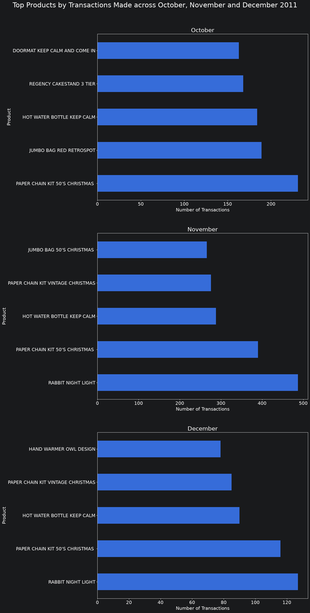

```python
# Focus on Q4 2011 and split it into individual months to examine
# whether the shift toward seasonal products develops gradually over time.
fourth_quarter_data=products_df[products_df['InvoiceDate'].between('2011-10-01','2011-12-31')].reset_index(drop=True)

# Aggregate the number of unique transactions for each product by month.
fourth_quarter_dive=fourth_quarter_data.groupby('StockCode').resample('ME', on='InvoiceDate')['InvoiceNo'].nunique().reset_index()

# Add product names using the StockCode-to-description mapping created earlier.
product_names = products_df.groupby('StockCode')['Description'].agg(lambda x: x.value_counts().index[0])
fourth_quarter_dive['Description'] = fourth_quarter_dive['StockCode'].map(product_names)

# Convert month-end dates into monthly periods for easier filtering.
fourth_quarter_dive['InvoiceDate']=fourth_quarter_dive['InvoiceDate'].dt.to_period('M')

# Identify the five products appearing in the largest number of transactions
# separately for October, November and December 2011.
october=fourth_quarter_dive[fourth_quarter_dive['InvoiceDate']=='2011-10'].groupby('StockCode')[['InvoiceNo','Description']].agg({ 'InvoiceNo': 'sum', 'Description': 'first'}).sort_values('InvoiceNo', ascending=False).head()
november=fourth_quarter_dive[fourth_quarter_dive['InvoiceDate']=='2011-11'].groupby('StockCode')[['InvoiceNo','Description']].agg({ 'InvoiceNo': 'sum', 'Description': 'first'}).sort_values('InvoiceNo', ascending=False).head()
december=fourth_quarter_dive[fourth_quarter_dive['InvoiceDate']=='2011-12'].groupby('StockCode')[['InvoiceNo','Description']].agg({ 'InvoiceNo': 'sum', 'Description': 'first'}).sort_values('InvoiceNo', ascending=False).head()

# Visualize the monthly leaders to examine how the Q4 product structure
# changes as the Christmas period approaches.
fig, axes = plt.subplots(3,1, figsize=(15,30))

october.plot(x='Description', y='InvoiceNo', kind='barh', ax=axes[0], legend=False)
november.plot(x='Description', y='InvoiceNo', kind='barh', ax=axes[1], legend=False)
december.plot(x='Description', y='InvoiceNo', kind='barh', ax=axes[2], legend=False)

axes[0].set_title('October', fontsize=20)
axes[1].set_title('November', fontsize=20)
axes[2].set_title('December', fontsize=20)

for ax in axes:
    ax.set_ylabel('Product', fontsize=16)
    ax.set_xlabel('Number of Transactions', fontsize=16)
    ax.tick_params(axis='both', labelsize=16)

plt.suptitle('Top Products by Transactions Made across October, November and December 2011', fontsize=24)
plt.tight_layout(rect=[0,0,1,0.96], h_pad=5)

# A closer examination of Q4 partially supports the hypothesis that the change
# in product leaders is driven by seasonal Christmas demand. As the holiday
# period approaches, Christmas-themed products become increasingly prominent
# among the most frequently purchased items.
#
# October, the month furthest from Christmas in this comparison, still resembles
# the structure observed in the previous quarters: several regular overall leaders,
# such as JUMBO BAG RED RETROSPOT and REGENCY CAKESTAND 3 TIER, remain among
# the top products, although PAPER CHAIN KIT 50'S CHRISTMAS already appears.
#
# In November, transaction volumes increase substantially across the leading products.
# This is consistent with the broader analysis, where November is the strongest month
# across several activity metrics, including transaction volume. Christmas-related
# products also become more visible among the monthly leaders.
#
# By December, seasonal products occupy an even larger share of the top positions.
# December contains only the first nine days of data, so its absolute transaction
# counts should not be directly compared with the complete October and November periods.
#
# RABBIT NIGHT LIGHT is a notable exception to the seasonal pattern. It becomes the
# transaction leader in both November and December despite not being an obviously
# Christmas-related product and not appearing among the October leaders.
# Its behavior does not appear anomalous in the broader dataset, however, since it is
# not among the overall transaction leaders. One possible explanation is that the product
# entered the catalogue relatively late, but the available dataset does not provide
# enough information to confirm this.
#
# Overall, no unusual transaction-volume anomalies are observed within Q4. The changing
# composition of the leading products appears largely consistent with seasonal demand
# and the generally elevated level of store activity toward the end of the year.
```

```python
# Check whether RABBIT NIGHT LIGHT may have appeared only recently in the catalogue,
# which could potentially explain its strong position in November and December.
december.loc[december['Description']=='RABBIT NIGHT LIGHT']
```

| StockCode | InvoiceNo | Description |
| --- | --- | --- |
| 23084 | 127 | RABBIT NIGHT LIGHT |

```python
# Identify the earliest recorded transaction for RABBIT NIGHT LIGHT.
products_df[products_df['StockCode']==23084]['InvoiceDate'].min()

# The product first appears in May 2011, so its late-year leadership cannot be
# explained by a recent introduction to the catalogue.
# The available dataset does not provide enough information to determine why
# RABBIT NIGHT LIGHT becomes particularly popular in November and December.
```

```
Timestamp('2011-05-10 14:20:00')
```

The transaction-frequency analysis reveals a relatively clear group of products that are purchased consistently across a large number of separate transactions.

There is also substantial overlap between the leaders by transaction frequency and the products previously identified among the leaders by total units sold. This suggests that the strongest products generally achieve high sales through **frequent purchases across many different transactions**, rather than relying primarily on a small number of exceptionally large orders.

The quarterly analysis further shows that these leading products are generally **stable over time**. Products occupying high positions in the overall ranking repeatedly appear among the quarterly leaders, indicating persistent demand throughout the year rather than isolated short-term spikes.

The main exception is **Q4 2011**, where the composition of the top products changes considerably. A closer month-by-month examination suggests that this shift is largely associated with **seasonal Christmas demand**. October still resembles the structure observed in the previous quarters, while Christmas-themed products become increasingly prominent as the holiday period approaches.

November records substantially higher transaction counts among its leading products, which is consistent with the broader analysis identifying it as the strongest month across several activity metrics. December contains only the first nine days of data, so its absolute transaction counts are not directly comparable with the complete October and November periods. Nevertheless, Christmas-related products occupy an even larger share of its leading positions.

One notable exception is **RABBIT NIGHT LIGHT**, which becomes the transaction leader in both November and December despite not being an obviously seasonal product. A separate check shows that it had already appeared in the dataset in **May 2011**, ruling out a recent introduction to the catalogue as an explanation. The available data does not provide enough information to determine the reason for its late-year increase in popularity.

Overall, no unusual transaction-volume anomalies are observed. The analysis points to a **stable core of frequently purchased products**, with the major late-year changes in the ranking largely consistent with seasonal demand and the general increase in store activity toward the end of the year.

### Best-Selling Products by Revenue Generated

```python
# Add a Revenue column to the product-level dataframe to enable the analysis
# of which products generated the most revenue.
products_df['Revenue']=products_df['Quantity']*products_df['UnitPrice']
```

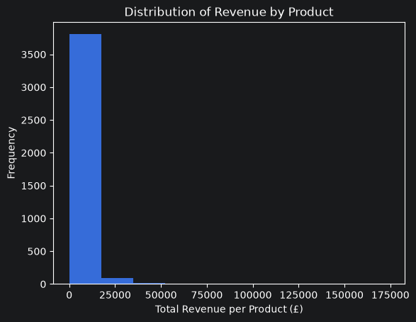

```python
# Aggregate total revenue by product and examine its distribution
# to identify whether a distinct group of revenue leaders exists.
products_revenue=products_df.groupby('StockCode')[['Revenue', 'Description']].agg({'Revenue': 'sum', 'Description': lambda x: x.value_counts().index[0]}).sort_values('Revenue', ascending=False)

ax = products_revenue.plot(y='Revenue', kind='hist', bins=10, legend=False)
ax.set_title('Distribution of Revenue by Product')
ax.set_xlabel('Total Revenue per Product (£)')

# Similar to the transaction-volume analysis, the distribution is strongly right-skewed.
# Most products generate relatively limited revenue, while a clearly separated tail
# of revenue leaders appears above approximately £37,500.
```

```python
# Count the products belonging to the previously identified high-revenue tail
# above £37,500.
products_revenue[products_revenue['Revenue']>37500].nunique()

# Only 18 products exceed this threshold, confirming that high revenue is
# concentrated among a relatively small and clearly defined group of products.
```

```
Revenue        18
Description    18
dtype: int64
```

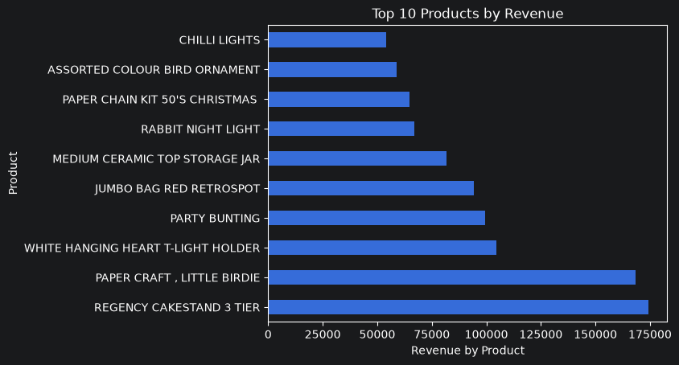

```python
# Examine the top 10 products by total revenue generated.
ax = products_revenue.head(10).plot(x='Description', y='Revenue', kind='barh', legend=False)

ax.set_title('Top 10 Products by Revenue')
ax.set_xlabel('Revenue by Product')
ax.set_ylabel('Product')
# REGENCY CAKESTAND 3 TIER and PAPER CRAFT, LITTLE BIRDIE clearly stand out
# as the two strongest revenue leaders, each generating around £170,000.
# Their revenue is approximately 75% higher than that of most of the remaining
# products in the top 10.
#
# However, PAPER CRAFT, LITTLE BIRDIE must be interpreted with caution.
# The previous analysis showed that all 80,995 units of this product were sold
# in a single transaction, meaning that its exceptionally high revenue is driven
# by one unusually large purchase rather than persistent demand.
```

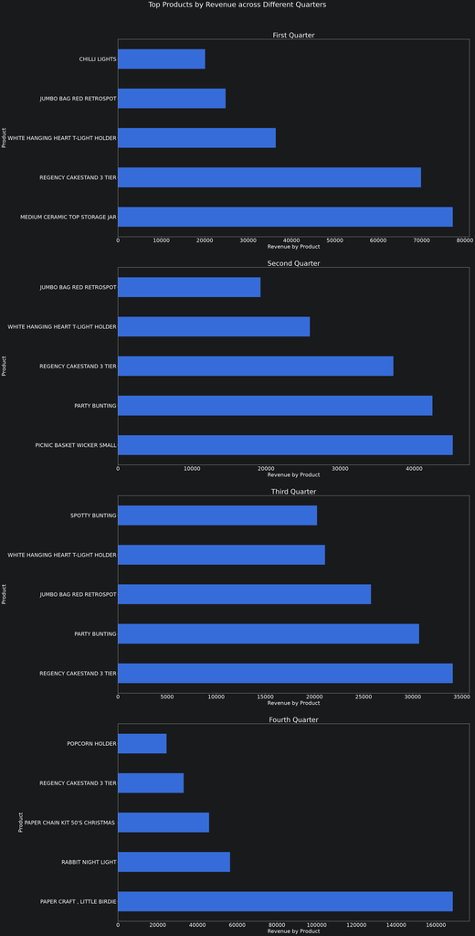

```python
# Analyze the stability of the highest-revenue products over time by calculating
# total revenue generated by each product across different quarters.

# Reset the index before resampling to avoid index-alignment issues.
revenue_df = revenue_df.reset_index(drop=True)

# Aggregate revenue by StockCode and quarter.
products_revenue_dynamic=revenue_df.groupby('StockCode').resample('QE', on='InvoiceDate')['Revenue'].sum().reset_index()

# Map each StockCode to its most frequently occurring product description.
product_names = products_df.groupby('StockCode')['Description'].agg(lambda x: x.value_counts().index[0])
products_revenue_dynamic['Description'] = products_revenue_dynamic['StockCode'].map(product_names)

# Convert quarter-end dates into quarterly periods and divide the data
# into four comparable periods.
products_revenue_dynamic['InvoiceDate']=products_revenue_dynamic['InvoiceDate'].dt.to_period('Q')

first_quarter=products_revenue_dynamic[products_revenue_dynamic['InvoiceDate'].astype(str).isin(['2010Q4', '2011Q1'])].groupby('StockCode')[['Revenue', 'Description']].agg({'Revenue': 'sum', 'Description': 'first'})
second_quarter=products_revenue_dynamic[products_revenue_dynamic['InvoiceDate']=='2011Q2'].groupby('StockCode')[['Revenue', 'Description']].agg({'Revenue': 'sum', 'Description': 'first'})
third_quarter=products_revenue_dynamic[products_revenue_dynamic['InvoiceDate']=='2011Q3'].groupby('StockCode')[['Revenue', 'Description']].agg({'Revenue': 'sum', 'Description': 'first'})
fourth_quarter=products_revenue_dynamic[products_revenue_dynamic['InvoiceDate']=='2011Q4'].groupby('StockCode')[['Revenue', 'Description']].agg({'Revenue': 'sum', 'Description': 'first'})

# Identify the five highest-revenue products in each period and compare
# how the composition of revenue leaders changes over time.
#
# December 2010 is combined with Q1 2011 because the dataset contains
# only one month of observations for 2010.
fig, axes= plt.subplots(4,1, figsize=(30,60))

first_quarter.sort_values('Revenue', ascending=False).head().plot(x='Description', y='Revenue', kind='barh', ax=axes[0], legend=False)
second_quarter.sort_values('Revenue', ascending=False).head().plot(x='Description', y='Revenue', kind='barh', ax=axes[1], legend=False)
third_quarter.sort_values('Revenue', ascending=False).head().plot(x='Description', y='Revenue', kind='barh', ax=axes[2], legend=False)
fourth_quarter.sort_values('Revenue', ascending=False).head().plot(x='Description', y='Revenue', kind='barh', ax=axes[3], legend=False)

axes[0].set_title('First Quarter', fontsize=30)
axes[1].set_title('Second Quarter', fontsize=30)
axes[2].set_title('Third Quarter', fontsize=30)
axes[3].set_title('Fourth Quarter', fontsize=30)

for ax in axes.flat:
    ax.set_ylabel('Product', fontsize=24)
    ax.set_xlabel('Revenue by Product', fontsize=24)
    ax.tick_params(axis='both', labelsize=24)

plt.suptitle('Top Products by Revenue across Different Quarters', fontsize=32)
plt.tight_layout(rect=[0,0,1,0.96], h_pad=5)

# Most of the main revenue-generating products show relatively stable performance
# over time and repeatedly appear among the quarterly leaders. Products such as
# REGENCY CAKESTAND 3 TIER, PARTY BUNTING, JUMBO BAG RED RETROSPOT and
# WHITE HANGING HEART T-LIGHT HOLDER appear in several periods, indicating that
# their strong overall revenue is supported by recurring demand rather than
# a single short-lived spike.
#
# PAPER CRAFT, LITTLE BIRDIE and RABBIT NIGHT LIGHT have already been examined
# separately and represent less typical cases in the dataset.
#
# Another interesting case is PICNIC BASKET WICKER SMALL. It becomes the leading
# revenue-generating product in Q2, but does not appear among the top products
# in the other quarters. Moreover, it was not identified among the leaders by
# total units sold or by number of transactions.
#
# This makes PICNIC BASKET WICKER SMALL worth examining separately, since its
# Q2 revenue leadership may have been driven by a different mechanism than the
# consistently high sales volume or transaction frequency observed for many
# of the store's other leading products.
```

```python
# Identify the StockCode of PICNIC BASKET WICKER SMALL in order to examine
# its transaction history in more detail.
second_quarter.loc[second_quarter['Description']=='PICNIC BASKET WICKER SMALL']
```

| StockCode | Revenue | Description |
| --- | --- | --- |
| 22502 | 45203.98 | PICNIC BASKET WICKER SMALL |

```python
# Examine the overall transaction profile of PICNIC BASKET WICKER SMALL:
# the number of unique transactions, total units sold, and all recorded unit prices.
products_df[products_df['StockCode']==22502][['InvoiceNo', 'Quantity', 'UnitPrice']].agg({'InvoiceNo':'nunique', 'Quantity':'sum', 'UnitPrice':'unique'})

# The product appears in 463 different transactions and 1,937 units were sold,
# which rules out a case similar to PAPER CRAFT, LITTLE BIRDIE, where the result
# was driven by a single exceptionally large transaction.
#
# However, the price distribution reveals a suspicious value of £649.50,
# while the remaining recorded prices are much lower and lie within a relatively
# normal range. This unusually high price may explain the product's strong Q2
# revenue performance and therefore requires separate investigation.
```

```
InvoiceNo                                                  463
Quantity                                                  1937
UnitPrice    [5.95, 4.95, 8.47, 8.29, 10.79, 8.95, 649.5, 2.0]
dtype: object
```

```python
# Examine the monthly transaction activity of PICNIC BASKET WICKER SMALL
# to understand whether its strong Q2 performance was driven by an isolated event
# or by consistently high demand during the quarter.
products_df[products_df['StockCode']==22502].resample('ME', on='InvoiceDate')['InvoiceNo'].nunique()

# The product was regularly purchased throughout the observation period,
# confirming that it was not an isolated or rarely traded item.
#
# However, transaction activity was particularly strong during Q2 2011
# (April–June), with April and May recording the highest monthly transaction counts.
# This suggests that the product's Q2 leadership was at least partly supported
# by genuinely elevated sales activity during this period.
```

```
InvoiceDate
2010-12-31    52
2011-01-31    45
2011-02-28    60
2011-03-31    64
2011-04-30    68
2011-05-31    88
2011-06-30    39
2011-07-31    29
2011-08-31    14
2011-09-30     4
Freq: ME, Name: InvoiceNo, dtype: int64
```

```python
# Investigate the unusual £649.50 price observed for PICNIC BASKET WICKER SMALL.
products_df.loc[(products_df['StockCode']==22502) & (products_df['UnitPrice']==649.5)]

# The unusually high price is explained by the product description:
# these transactions refer to "PICNIC BASKET WICKER 60 PIECES", meaning that
# £649.50 represents the price of a 60-piece batch rather than a single basket.
#
# Both transactions were made by the same customer (CustomerID 15098) on
# 10 June 2011. The customer purchased 61 batches in total, corresponding to
# 3,660 baskets and approximately £39,619.50 in revenue.
#
# This unusually large bulk purchase explains why StockCode 22502 became the
# highest-revenue product in Q2 despite not appearing among the overall leaders
# by transaction count or quantity sold.
#
# The dataset does not provide enough information to determine why this customer
# purchased such an unusually large quantity.
```

|  | InvoiceNo | StockCode | Description | Quantity | InvoiceDate | UnitPrice | CustomerID | Country | Revenue |
| --- | --- | --- | --- | --- | --- | --- | --- | --- | --- |
| 214426 | 556444 | 22502 | PICNIC BASKET WICKER 60 PIECES | 60 | 2011-06-10 15:28:00 | 649.5 | 15098.0 | United Kingdom | 38970.0 |
| 214427 | 556446 | 22502 | PICNIC BASKET WICKER 60 PIECES | 1 | 2011-06-10 15:33:00 | 649.5 | 15098.0 | United Kingdom | 649.5 |

Revenue is strongly concentrated among a relatively small group of products, with only **18 products generating more than £37,500** over the observation period.

Most leading products demonstrate **consistent revenue performance across multiple quarters**, suggesting recurring demand rather than dependence on isolated transactions. However, several notable exceptions show that high revenue can also result from unusually large individual purchases.

In particular, **PAPER CRAFT, LITTLE BIRDIE** achieved its exceptional overall revenue almost entirely through a single transaction, while the Q2 leadership of **PICNIC BASKET WICKER SMALL** was largely explained by a large bulk purchase of 60-piece batches.

Overall, the analysis shows that **high product revenue can arise through different mechanisms**: persistent demand over time or exceptional high-value transactions. Therefore, revenue figures alone should be interpreted together with transaction frequency, quantities sold, and individual transaction characteristics.

## Product Analysis Summary

The product analysis began with **total quantity sold as the primary measure of product popularity**. However, the results demonstrated that product performance cannot be reliably evaluated using a single metric. This led to the analysis being expanded to two additional dimensions: **transaction frequency and total revenue**.

The transition to transaction-frequency analysis was motivated by the unusual case of **PAPER CRAFT, LITTLE BIRDIE**. Despite appearing as the overall leader by quantity sold, all **80,995 units were purchased in a single transaction**, showing how an exceptionally large individual order can strongly distort a quantity-based ranking.

Revenue was introduced as another perspective after examining the relationship between **product price and total quantity sold**. The initial intuition that more expensive products would generally be purchased less frequently was not supported by the data: the correlation was only approximately **-0.10**, indicating almost no linear relationship between these variables.

Each of the three perspectives was therefore analyzed both through **overall product rankings and their stability over time**, allowing persistent product performance to be distinguished from isolated short-term or transaction-specific effects.

### Key Findings

- **Quantity sold:** several apparent leaders were strongly affected by unusually large purchases. In particular, PAPER CRAFT, LITTLE BIRDIE and MEDIUM CERAMIC TOP STORAGE JAR demonstrate why total quantity alone can provide a misleading picture of genuine product popularity.
- **Transaction frequency:** the analysis reveals a much more stable core of repeatedly purchased products. The strongest products generally appear across a large number of separate transactions and remain competitive over multiple periods. The main changes occur toward the end of the year, when **seasonal Christmas demand** becomes increasingly visible.
- **Revenue:** high revenue can be generated through different mechanisms. Most leading products show persistent performance over time, while exceptional cases demonstrate that individual high-value purchases can also temporarily dominate the ranking. Revenue is therefore most informative when interpreted together with transaction frequency and quantity sold.

### Strongest Products

Considering all three dimensions together, **WHITE HANGING HEART T-LIGHT HOLDER, JUMBO BAG RED RETROSPOT, and ASSORTED COLOUR BIRD ORNAMENT** emerge as the strongest overall products in the dataset. All three appear among the **top 10 products by quantity sold, number of unique transactions, and total revenue**, while also demonstrating relatively stable performance over time.

**REGENCY CAKESTAND 3 TIER** also deserves particular attention. It is the **overall revenue leader** and one of the strongest products by transaction frequency, while repeatedly appearing among the leading products across different periods. Although it does not satisfy the same top-10 criterion across all three metrics, its combination of high revenue, frequent purchases, and temporal stability makes it one of the store's most commercially important products.

Several other products show strong performance in particular dimensions, including **PARTY BUNTING** in revenue and transaction frequency and **PACK OF 72 RETROSPOT CAKE CASES** in transaction frequency and quantity sold.

At the same time, several unusual cases demonstrate why individual rankings require careful interpretation. **PAPER CRAFT, LITTLE BIRDIE** owes its extraordinary quantity and revenue primarily to a single transaction, while **MEDIUM CERAMIC TOP STORAGE JAR** shows an unusually concentrated quantity distribution over time. **RABBIT NIGHT LIGHT** displays a notable late-year increase in transaction frequency, while products such as **PAPER CHAIN KIT 50'S CHRISTMAS** illustrate the influence of seasonal demand.

Overall, the analysis suggests that there is **no single universal measure of the "best" product**. Quantity captures sales volume, transaction frequency reflects repeated purchasing activity, and revenue measures financial contribution. The strongest evidence of sustained product success therefore comes from products that perform well **across several metrics and remain competitive over time**, rather than those occupying the first position in a single ranking.

## Customer Analysis

This section focuses on the store's **customer structure and its most important buyers**.

We begin by identifying the leading customers from two perspectives: **transaction frequency** and **total revenue generated**. This allows us to distinguish customers who purchase particularly often from those who make the largest financial contribution to the store.

We then examine how these leading customers perform **over time**, determining whether their importance is driven by isolated periods of unusually high activity or represents a more stable and recurring purchasing pattern.

Finally, we take a closer look at the resulting group of **key customers**. We investigate which products are repeatedly purchased across this group to identify potential **favorites among the store's strongest buyers**, and examine their **geographic distribution** to understand where these customers are located.

Overall, the analysis aims to provide a clearer picture of **who the store's most important customers are, how consistently they contribute to its activity, and what purchasing patterns they share**.

### Customer Data Preparation

```python
# Inspect transactions with missing CustomerID values to understand their structure
# and determine whether they differ noticeably from regular transaction records.
df.loc[df['CustomerID'].isna()]

# The records appear structurally similar to regular transactions.
# However, the displayed rows all originate from the United Kingdom.
# We therefore check whether missing CustomerID values are concentrated
# exclusively in the UK or also occur in other countries.
```

|  | InvoiceNo | StockCode | Description | Quantity | InvoiceDate | UnitPrice | CustomerID | Country |
| --- | --- | --- | --- | --- | --- | --- | --- | --- |
| 605 | 536414 | 22139 | NaN | 56 | 2010-12-01 11:52:00 | 0.00 | NaN | United Kingdom |
| 1407 | 536544 | 21773 | DECORATIVE ROSE BATHROOM BOTTLE | 1 | 2010-12-01 14:32:00 | 2.51 | NaN | United Kingdom |
| 1408 | 536544 | 21774 | DECORATIVE CATS BATHROOM BOTTLE | 2 | 2010-12-01 14:32:00 | 2.51 | NaN | United Kingdom |
| 1409 | 536544 | 21786 | POLKADOT RAIN HAT | 4 | 2010-12-01 14:32:00 | 0.85 | NaN | United Kingdom |
| 1410 | 536544 | 21787 | RAIN PONCHO RETROSPOT | 2 | 2010-12-01 14:32:00 | 1.66 | NaN | United Kingdom |
| ... | ... | ... | ... | ... | ... | ... | ... | ... |
| 536275 | 581498 | 85099B | JUMBO BAG RED RETROSPOT | 5 | 2011-12-09 10:26:00 | 4.13 | NaN | United Kingdom |
| 536276 | 581498 | 85099C | JUMBO BAG BAROQUE BLACK WHITE | 4 | 2011-12-09 10:26:00 | 4.13 | NaN | United Kingdom |
| 536277 | 581498 | 85150 | LADIES & GENTLEMEN METAL SIGN | 1 | 2011-12-09 10:26:00 | 4.96 | NaN | United Kingdom |
| 536278 | 581498 | 85174 | S/4 CACTI CANDLES | 1 | 2011-12-09 10:26:00 | 10.79 | NaN | United Kingdom |
| 536279 | 581498 | DOT | DOTCOM POSTAGE | 1 | 2011-12-09 10:26:00 | 1714.17 | NaN | United Kingdom |

135037 rows × 8 columns

```python
# Check the geographic distribution of transactions with missing CustomerID values.
df[df['CustomerID'].isna()].groupby('Country')['Country'].count()

# Missing CustomerID values are not exclusive to the United Kingdom
# and also occur across several international markets.
#
# The strong dominance of the United Kingdom is expected, as the previous
# geographic analysis showed that the UK accounts for the vast majority
# of the store's transactions.
```

```
Country
Bahrain                2
EIRE                 709
France                66
Hong Kong            284
Israel                47
Portugal              39
Switzerland          117
United Kingdom    133572
Unspecified          201
Name: Country, dtype: int64
```

```python
# Check whether rows with missing CustomerID can be matched to otherwise identical
# rows in the dataset by comparing all columns except CustomerID.
columns_without_customer = df.columns.drop('CustomerID')

duplicates_without_customer = df[df.duplicated(subset=columns_without_customer, keep=False)]

duplicates_without_customer

# No such matches are found, so missing CustomerID values cannot be recovered
# through otherwise identical records.
#
# We therefore broaden the search and check whether transactions containing
# missing CustomerID values share their InvoiceNo with any transactions where
# CustomerID is known.
```

|  | InvoiceNo | StockCode | Description | Quantity | InvoiceDate | UnitPrice | CustomerID | Country |
| --- | --- | --- | --- | --- | --- | --- | --- | --- |

```python
# Collect InvoiceNo values associated with missing CustomerID records.
transactions_without_customerid=df[df['CustomerID'].isna()]['InvoiceNo'].to_list()

# Check whether any of these transactions also contain records with a known CustomerID.
df[(df['InvoiceNo'].isin(transactions_without_customerid)) & (~df['CustomerID'].isna())]

# No matches are found. Transactions with missing CustomerID values never share
# their InvoiceNo with records where the customer is identified.
#
# Together with the previous check, this indicates that the missing CustomerID
# values cannot be reliably recovered from other records available in the dataset.
```

|  | InvoiceNo | StockCode | Description | Quantity | InvoiceDate | UnitPrice | CustomerID | Country |
| --- | --- | --- | --- | --- | --- | --- | --- | --- |

```python
# Examine rows classified as discounts to determine whether they can provide
# useful information about customer behavior or purchasing patterns.
df[df['StockCode']=='D']

# All discount entries are recorded with negative quantities and cancellation
# invoice numbers (starting with 'C'), suggesting that they are not regular purchases.
# We therefore investigate whether these records can be linked to other transactions.
```

|  | InvoiceNo | StockCode | Description | Quantity | InvoiceDate | UnitPrice | CustomerID | Country |
| --- | --- | --- | --- | --- | --- | --- | --- | --- |
| 141 | C536379 | D | Discount | -1 | 2010-12-01 09:41:00 | 27.50 | 14527.0 | United Kingdom |
| 8886 | C537164 | D | Discount | -1 | 2010-12-05 13:21:00 | 29.29 | 14527.0 | United Kingdom |
| 14240 | C537597 | D | Discount | -1 | 2010-12-07 12:34:00 | 281.00 | 15498.0 | United Kingdom |
| 19081 | C537857 | D | Discount | -1 | 2010-12-08 16:00:00 | 267.12 | 17340.0 | United Kingdom |
| 30695 | C538897 | D | Discount | -1 | 2010-12-15 09:14:00 | 5.76 | 16422.0 | United Kingdom |
| ... | ... | ... | ... | ... | ... | ... | ... | ... |
| 475538 | C577227 | D | Discount | -1 | 2011-11-18 12:06:00 | 19.82 | 14527.0 | United Kingdom |
| 475539 | C577227 | D | Discount | -1 | 2011-11-18 12:06:00 | 16.76 | 14527.0 | United Kingdom |
| 489022 | C578239 | D | Discount | -1 | 2011-11-23 12:29:00 | 26.33 | 14912.0 | Italy |
| 511232 | C579884 | D | Discount | -1 | 2011-11-30 17:34:00 | 20.53 | 14527.0 | United Kingdom |
| 511466 | C579908 | D | Discount | -1 | 2011-12-01 08:49:00 | 28.68 | 14527.0 | United Kingdom |

77 rows × 8 columns

```python
# Check whether any discounts are recorded outside cancellation invoices.
df[(df['StockCode']=='D') & (~df['InvoiceNo'].astype(str).str.contains('^C'))]

# No such records are found: every discount entry belongs to a cancellation invoice.
```

|  | InvoiceNo | StockCode | Description | Quantity | InvoiceDate | UnitPrice | CustomerID | Country |
| --- | --- | --- | --- | --- | --- | --- | --- | --- |

```python
# Check whether discount invoices contain other transaction lines that could
# reveal which products or operations the discounts are associated with.
discount_transactions=df[df['StockCode']=='D']['InvoiceNo'].to_list()

df[(df['InvoiceNo'].isin(discount_transactions)) & (df['StockCode']!='D')]

# Almost all discount invoices contain no other records. The only exception
# consists of two 'Manual' adjustments within the same invoice.
#
# Therefore, discount records cannot be directly linked to specific products
# or purchases through their InvoiceNo.
```

|  | InvoiceNo | StockCode | Description | Quantity | InvoiceDate | UnitPrice | CustomerID | Country |
| --- | --- | --- | --- | --- | --- | --- | --- | --- |
| 87389 | C543789 | M | Manual | -1 | 2011-02-11 17:10:00 | 856.48 | 17450.0 | United Kingdom |
| 87391 | C543789 | M | Manual | -1 | 2011-02-11 17:10:00 | 190.80 | 17450.0 | United Kingdom |

```python
# As an additional check, examine the transaction history of a customer with
# multiple discount records to determine whether they can be linked chronologically
# to previous purchases.
df[df['CustomerID'] == 14527].sort_values('InvoiceDate')

# The discount may appear without any preceding purchase in the available data.
# This makes it impossible to reliably determine which transaction the discount
# refers to using transaction history alone.
```

|  | InvoiceNo | StockCode | Description | Quantity | InvoiceDate | UnitPrice | CustomerID | Country |
| --- | --- | --- | --- | --- | --- | --- | --- | --- |
| 141 | C536379 | D | Discount | -1 | 2010-12-01 09:41:00 | 27.50 | 14527.0 | United Kingdom |
| 8838 | 537159 | 21258 | VICTORIAN SEWING BOX LARGE | 3 | 2010-12-05 13:17:00 | 12.75 | 14527.0 | United Kingdom |
| 8837 | 537159 | 84997B | RED 3 PIECE RETROSPOT CUTLERY SET | 2 | 2010-12-05 13:17:00 | 3.75 | 14527.0 | United Kingdom |
| 8836 | 537159 | 84997A | GREEN 3 PIECE POLKADOT CUTLERY SET | 1 | 2010-12-05 13:17:00 | 3.75 | 14527.0 | United Kingdom |
| 8835 | 537159 | 22072 | RED RETROSPOT TEA CUP AND SAUCER | 6 | 2010-12-05 13:17:00 | 3.75 | 14527.0 | United Kingdom |
| ... | ... | ... | ... | ... | ... | ... | ... | ... |
| 528587 | 581114 | 22975 | SPACEBOY CHILDRENS EGG CUP | 2 | 2011-12-07 12:19:00 | 1.25 | 14527.0 | United Kingdom |
| 528586 | 581114 | 22696 | WICKER WREATH LARGE | 1 | 2011-12-07 12:19:00 | 1.95 | 14527.0 | United Kingdom |
| 528585 | 581114 | 23344 | JUMBO BAG 50'S CHRISTMAS | 2 | 2011-12-07 12:19:00 | 2.08 | 14527.0 | United Kingdom |
| 528599 | 581114 | 23394 | POSTE FRANCE CUSHION COVER | 1 | 2011-12-07 12:19:00 | 3.75 | 14527.0 | United Kingdom |
| 528615 | 581114 | 22112 | CHOCOLATE HOT WATER BOTTLE | 3 | 2011-12-07 12:19:00 | 4.95 | 14527.0 | United Kingdom |

1010 rows × 8 columns

```python
# Finally, check whether removing the cancellation prefix reveals a corresponding
# original invoice.
df[(df['CustomerID'] == 14527) & (df['InvoiceNo']==536379)].sort_values('InvoiceDate')

# No corresponding original invoice is found.
```

|  | InvoiceNo | StockCode | Description | Quantity | InvoiceDate | UnitPrice | CustomerID | Country |
| --- | --- | --- | --- | --- | --- | --- | --- | --- |

### Treatment of Discount Records

Discount records were initially considered worth **retaining in `customer_df`**, as they could potentially provide additional information about customer behavior — for example, whether frequent or loyal customers receive discounts.

However, further investigation shows that the meaning of these records cannot be reliably determined. `Discount` entries appear exclusively within cancellation invoices, cannot generally be linked to specific purchases, and no corresponding original transactions can be identified.

As a result, there is **no evidence that these records represent customer rewards, loyalty incentives, or discounts associated with purchasing activity**. Their economic meaning remains unclear within the available dataset.

Therefore, the initial idea of specifically retaining `Discount` records for customer analysis is not supported by the data, and they will not be included in `customer_df`.

```python
# Create a customer-focused dataset containing only valid product purchases
# that can be reliably associated with an identified customer.
#
# Non-product records such as postage, commissions, fees, manual adjustments
# and discounts are excluded, together with transactions with non-positive
# quantities or prices.
#
# Rows with missing CustomerID are also excluded. As shown above, these customer
# identifiers cannot be reliably reconstructed from other records in the dataset.
non_revenue_codes = ['POST','DOT','C2','D','M','m','BANK CHARGES','AMAZONFEE','CRUK','B','S']

customer_df=df[(df['Quantity']>0) & (df['UnitPrice']>0) & (~df['StockCode'].astype(str).isin(non_revenue_codes)) & (~df['CustomerID'].isna())].copy()

# Convert CustomerID to integer format, since all missing identifiers have already been removed.
customer_df['CustomerID']=customer_df['CustomerID'].astype(int)
```

```python
customer_df.isna().sum()

# No missing values remain in the customer dataset.
# Interestingly, removing rows with missing CustomerID also eliminates all missing
# product descriptions. This indicates that records without Description are also
# associated with missing customer identifiers.
#
# Therefore, unlike in products_df, no separate reconstruction of missing
# descriptions is required for customer_df.
```

```
InvoiceNo      0
StockCode      0
Description    0
Quantity       0
InvoiceDate    0
UnitPrice      0
CustomerID     0
Country        0
dtype: int64
```

### Customer Transaction Frequency

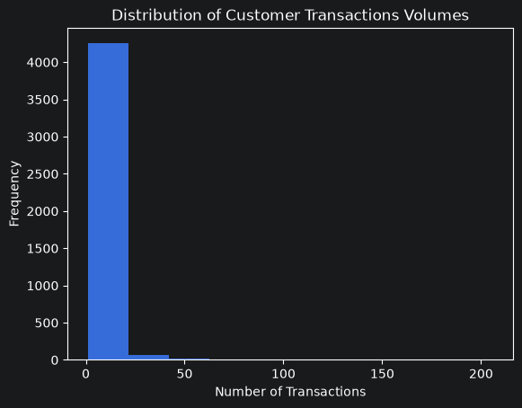

```python
# Examine the distribution of transaction volumes across customers
# to identify whether a small group of particularly active customers exists.
customer_transactions=customer_df.groupby('CustomerID')['InvoiceNo'].nunique().sort_values(ascending=False)

ax = customer_transactions.plot(y='InvoiceNo', kind='hist', bins=10)
ax.set_xlabel('Number of Transactions')
ax.set_title('Distribution of Customer Transactions Volumes')

# The distribution is strongly right-skewed: the vast majority of customers
# made relatively few transactions, while a small group stands out with
# substantially higher purchasing activity.
#
# Customers with more than 37 transactions form a clearly separated group,
# which can be examined as the store's most active customers.
```

```python
# Count the customers belonging to this high-activity group.
customer_transactions[customer_transactions>37].count()

# Only 25 customers made more than 37 transactions, confirming that the
# high-activity segment represents a small and clearly distinguished group
# within the overall customer base.
```

```
np.int64(25)
```

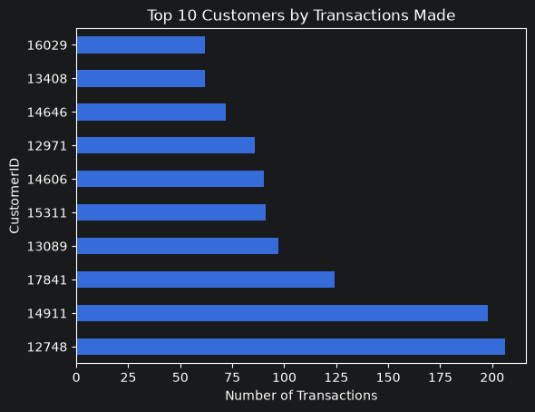

```python
# Identify the ten most active customers by the number of unique transactions
# to examine the structure within the high-activity customer segment.
ax = customer_transactions.head(10).plot(x='CustomerID', y='InvoiceNo', kind='barh')

ax.set_xlabel('Number of Transactions')
ax.set_title('Top 10 Customers by Transactions Made')

# Customers 12748 and 14911 stand out as the two clear leaders in transaction
# frequency, with more than 200 and almost 200 transactions respectively.
#
# Both are substantially ahead of the remaining top customers, indicating that
# even within the highly active customer segment, purchasing activity is strongly
# concentrated around a very small number of exceptional customers.
```

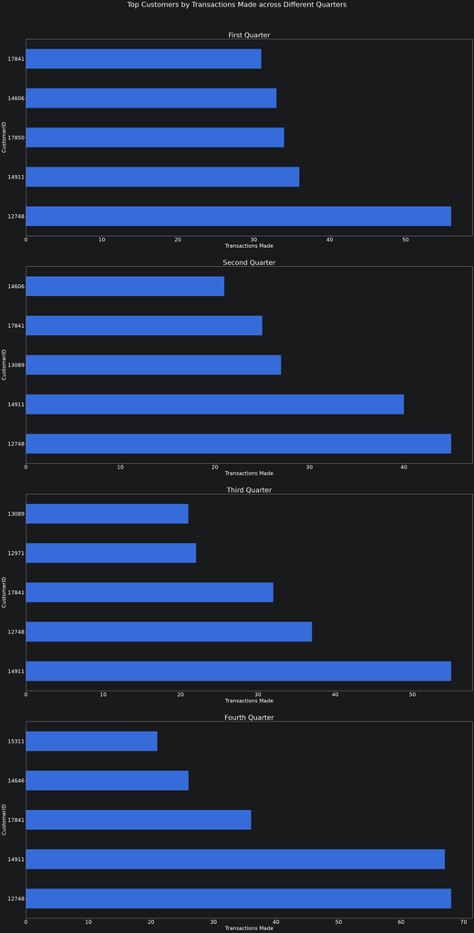

```python
# Examine whether the most active customers remain consistently active over time
# by comparing the number of unique transactions made by each customer across quarters.

# Reset the index to avoid alignment issues during the resampling operation.
customer_df=customer_df.reset_index(drop=True)

# Aggregate the number of unique transactions for each customer by quarter.
customer_transactions_dynamic=customer_df.groupby('CustomerID').resample('QE', on='InvoiceDate')['InvoiceNo'].nunique().reset_index()

# Convert quarter-end dates into quarterly periods for easier filtering.
customer_transactions_dynamic['InvoiceDate']=customer_transactions_dynamic['InvoiceDate'].dt.to_period('Q')

# Split the observation period into quarterly groups.
# December 2010 is combined with Q1 2011 because the dataset contains
# only one month of observations for 2010.
first_quarter=customer_transactions_dynamic[customer_transactions_dynamic['InvoiceDate'].astype(str).isin(['2010Q4', '2011Q1'])].groupby('CustomerID')['InvoiceNo'].sum()
second_quarter=customer_transactions_dynamic[customer_transactions_dynamic['InvoiceDate']=='2011Q2'].groupby('CustomerID')['InvoiceNo'].sum()
third_quarter=customer_transactions_dynamic[customer_transactions_dynamic['InvoiceDate']=='2011Q3'].groupby('CustomerID')['InvoiceNo'].sum()
fourth_quarter=customer_transactions_dynamic[customer_transactions_dynamic['InvoiceDate']=='2011Q4'].groupby('CustomerID')['InvoiceNo'].sum()

# Visualize the five most active customers in each period to evaluate
# the temporal stability of the transaction-frequency leaders.
fig, axes= plt.subplots(4,1, figsize=(30,60))

first_quarter.sort_values(ascending=False).head().plot(x='CustomerID', y='InvoiceNo', kind='barh', ax=axes[0], legend=False)
second_quarter.sort_values(ascending=False).head().plot(x='CustomerID', y='InvoiceNo', kind='barh', ax=axes[1], legend=False)
third_quarter.sort_values(ascending=False).head().plot(x='CustomerID', y='InvoiceNo', kind='barh', ax=axes[2], legend=False)
fourth_quarter.sort_values(ascending=False).head().plot(x='CustomerID', y='InvoiceNo', kind='barh', ax=axes[3], legend=False)

axes[0].set_title('First Quarter', fontsize=30)
axes[1].set_title('Second Quarter', fontsize=30)
axes[2].set_title('Third Quarter', fontsize=30)
axes[3].set_title('Fourth Quarter', fontsize=30)

for ax in axes.flat:
    ax.set_ylabel('CustomerID', fontsize=24)
    ax.set_xlabel('Transactions Made', fontsize=24)
    ax.tick_params(axis='both', labelsize=24)

plt.suptitle('Top Customers by Transactions Made across Different Quarters', fontsize=32)
plt.tight_layout(rect=[0,0,1,0.96], h_pad=5)

# The quarterly analysis confirms that the leading customers are remarkably
# stable over time. Most of the customers appearing among the overall transaction
# leaders repeatedly return to the top positions across different quarters.
#
# Customers 12748 and 14911 are particularly notable: both remain among the
# strongest customers throughout the entire observation period and consistently
# compete for the leading position in each quarter.
#
# No clear short-term anomalies or isolated spikes are visible among the main
# customer leaders. Their high overall transaction counts therefore appear to
# reflect sustained purchasing activity rather than unusually intensive activity
# during a single period.
```

The analysis reveals a **small and clearly defined group of highly active customers**. Only **25 customers** made more than 37 unique transactions during the observation period.

Among them, **Customer 12748 and Customer 14911 stand out as the two strongest transaction-frequency leaders**, with more than 200 and almost 200 transactions respectively, substantially exceeding the activity of the remaining top customers.

The quarterly analysis confirms that the leading customers are generally **stable over time rather than driven by short-term spikes**. In particular, Customers **12748 and 14911 remain among the strongest customers in every analyzed period**, repeatedly competing for the leading position.

Overall, the transaction-frequency analysis identifies a **persistent core of highly active customers**, with no major temporal anomalies among the principal leaders.

### Customer Revenue

```python
# Calculate the revenue generated by each transaction line.
# This allows us to evaluate customers not only by purchasing frequency,
# but also by their total financial contribution.
customer_df['Revenue']=customer_df['UnitPrice']*customer_df['Quantity']
```

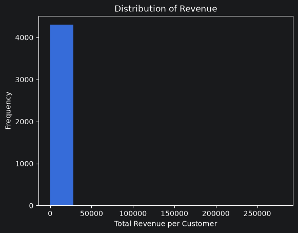

```python
# Calculate the total revenue generated by each customer and examine its distribution.
customer_revenue=customer_df.groupby('CustomerID')['Revenue'].sum()

ax = customer_revenue.plot(y='Revenue', kind='hist', bins=10)
ax.set_title('Distribution of Revenue')
ax.set_xlabel('Total Revenue per Customer')

# The distribution is strongly right-skewed: the vast majority of customers
# generate relatively moderate revenue, while a small group stands clearly
# apart with substantially higher total contributions.
```

```python
# Count customers generating more than £25,000 in total revenue
# to estimate the size of this high-value customer segment.
customer_revenue[customer_revenue>25000].count()

# Only 38 customers exceed this threshold, confirming that the high-value
# segment represents a small and clearly distinguished part of the customer base.
```

```
np.int64(38)
```

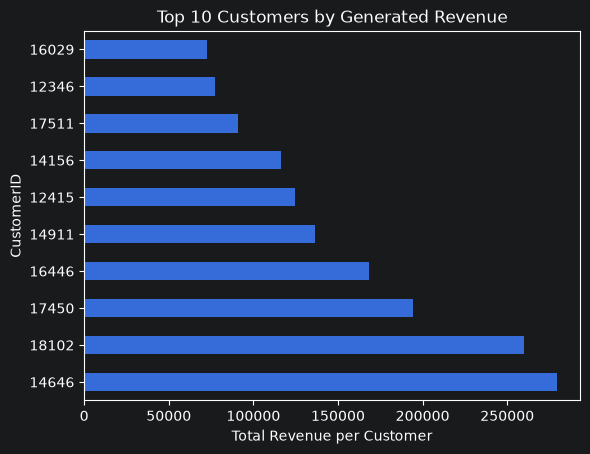

```python
# Identify the ten customers generating the highest total revenue
# to examine the structure of the high-value customer segment.
ax = customer_revenue.sort_values(ascending=False).head(10).plot(x='CustomerID', y='Revenue', kind='barh')

ax.set_xlabel('Total Revenue per Customer')
ax.set_title('Top 10 Customers by Generated Revenue')

# Customers 14646 and 18102 emerge as the two clear revenue leaders,
# generating substantially more revenue than the remaining top customers.
#
# A noticeable gap separates these two customers from the rest of the ranking,
# indicating an especially strong financial contribution from this pair.
```

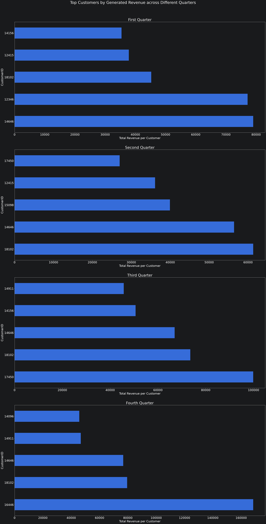

```python
# Analyze whether the customers generating the highest revenue remain consistent
# over time by comparing the leading customers across different quarters.

# Aggregate total revenue by customer and quarter.
customer_revenue_dynamic=customer_df.groupby('CustomerID').resample('QE', on='InvoiceDate')['Revenue'].sum().reset_index()

# Convert quarter-end dates into quarterly periods for easier filtering.
customer_revenue_dynamic['InvoiceDate']=customer_revenue_dynamic['InvoiceDate'].dt.to_period('Q')

# Split the observation period into four groups.
# December 2010 is included together with Q1 2011 due to the limited
# amount of data available for 2010.
first_quarter=customer_revenue_dynamic[customer_revenue_dynamic['InvoiceDate'].astype(str).isin(['2010Q4', '2011Q1'])].groupby('CustomerID')['Revenue'].sum().sort_values(ascending=False)
second_quarter=customer_revenue_dynamic[customer_revenue_dynamic['InvoiceDate']=='2011Q2'].groupby('CustomerID')['Revenue'].sum().sort_values(ascending=False)
third_quarter=customer_revenue_dynamic[customer_revenue_dynamic['InvoiceDate']=='2011Q3'].groupby('CustomerID')['Revenue'].sum().sort_values(ascending=False)
fourth_quarter=customer_revenue_dynamic[customer_revenue_dynamic['InvoiceDate']=='2011Q4'].groupby('CustomerID')['Revenue'].sum().sort_values(ascending=False)

# Visualize the five highest-revenue customers in each period
# to examine the stability of the main revenue leaders over time.
fig, axes= plt.subplots(4,1, figsize=(30,60))

first_quarter.head().plot(x='CustomerID', y='Revenue', kind='barh', ax=axes[0], legend=False)
second_quarter.head().plot(x='CustomerID', y='Revenue', kind='barh', ax=axes[1], legend=False)
third_quarter.head().plot(x='CustomerID', y='Revenue', kind='barh', ax=axes[2], legend=False)
fourth_quarter.head().plot(x='CustomerID', y='Revenue', kind='barh', ax=axes[3], legend=False)

axes[0].set_title('First Quarter', fontsize=30)
axes[1].set_title('Second Quarter', fontsize=30)
axes[2].set_title('Third Quarter', fontsize=30)
axes[3].set_title('Fourth Quarter', fontsize=30)

for ax in axes.flat:
    ax.set_ylabel('CustomerID', fontsize=24)
    ax.set_xlabel('Total Revenue per Customer', fontsize=24)
    ax.tick_params(axis='both', labelsize=24)

plt.suptitle('Top Customers by Generated Revenue across Different Quarters', fontsize=32)
plt.tight_layout(rect=[0,0,1,0.96], h_pad=5)

# The quarterly analysis shows that the two main overall revenue leaders,
# Customers 14646 and 18102, maintain a strong presence across different periods,
# indicating a relatively stable contribution over time.
#
# However, two notable cases stand out. Customer 17450 appears among the leaders
# only in Q2 and Q3, but generates exceptionally high revenue in Q3.
#
# Customer 16446 represents an even more extreme case: the customer does not appear
# among the leaders in the other periods, but dominates Q4 and generates the highest
# revenue recorded for any single customer in any analyzed quarter.
#
# These two unusual patterns will be examined separately to understand the source
# of their exceptionally high revenue during specific periods.
```

```python
# Examine Customer 17450 in greater detail by aggregating the number of unique
# transactions and generated revenue by month.

# This allows us to identify whether the unusually high Q3 revenue was generated
# gradually throughout the quarter or concentrated in a specific month.
customer_df[customer_df['CustomerID']==17450].resample('ME', on='InvoiceDate')[['InvoiceNo', 'Revenue']].agg({'InvoiceNo': 'nunique', 'Revenue': 'sum'})

# September 2011 clearly stands out as the main source of Customer 17450's
# exceptionally high revenue in Q3. During this month, the customer made
# 11 transactions and generated £75,412.64 in revenue.
#
# Although November also shows similarly high purchasing activity with
# 10 transactions, the generated revenue was substantially lower at £27,869.45.
#
# This suggests that the September spike cannot be explained by transaction
# frequency alone and is likely associated with unusually high-value purchases.
# Therefore, the individual September transactions should be examined next.
```

| InvoiceDate | InvoiceNo | Revenue |
| --- | --- | --- |
| 2010-12-31 | 2 | 2028.84 |
| 2011-01-31 | 3 | 18620.20 |
| 2011-02-28 | 0 | 0.00 |
| 2011-03-31 | 3 | 13500.50 |
| 2011-04-30 | 2 | 3585.04 |
| 2011-05-31 | 4 | 18025.68 |
| 2011-06-30 | 1 | 5405.48 |
| 2011-07-31 | 3 | 8485.14 |
| 2011-08-31 | 4 | 15959.46 |
| 2011-09-30 | 11 | 75412.64 |
| 2011-10-31 | 2 | 3935.96 |
| 2011-11-30 | 10 | 27869.45 |
| 2011-12-31 | 1 | 1562.40 |

```python
# Inspect the individual products purchased by Customer 17450 during September 2011
# to understand what generated the unusually high monthly revenue.
customer_df.loc[(customer_df['CustomerID']==17450) & (customer_df['InvoiceDate'].between('2011-09-01', '2011-09-30'))]

# The September revenue spike is not driven by unusually expensive individual products.
# Instead, Customer 17450 purchased very large quantities of relatively inexpensive items,
# frequently ordering several hundred units of the same product.
#
# The purchases also show recurring product patterns. Many items are related to mugs,
# kitchenware and other kitchen products, alongside bathroom-related signs and accessories
# and various decorative items such as photo frames and interior signs.
#
# This purchasing behavior strongly resembles bulk commercial procurement rather than
# typical individual consumer activity. The product mix could potentially be consistent
# with a hospitality or restaurant-related business, although the available data does not
# provide enough information to identify the customer's actual business type.
#
# Overall, Customer 17450's exceptional Q3 performance can therefore be explained by
# unusually large bulk purchases concentrated particularly in September 2011.
```

|  | InvoiceNo | StockCode | Description | Quantity | InvoiceDate | UnitPrice | CustomerID | Country | Revenue |
| --- | --- | --- | --- | --- | --- | --- | --- | --- | --- |
| 227786 | 565589 | 21181 | PLEASE ONE PERSON METAL SIGN | 192 | 2011-09-05 13:52:00 | 2.40 | 17450 | United Kingdom | 460.80 |
| 227787 | 565589 | 82583 | HOT BATHS METAL SIGN | 96 | 2011-09-05 13:52:00 | 2.40 | 17450 | United Kingdom | 230.40 |
| 244843 | 567377 | 23113 | PANTRY CHOPPING BOARD | 186 | 2011-09-20 09:55:00 | 5.15 | 17450 | United Kingdom | 957.90 |
| 244937 | 567381 | 21876 | POTTERING MUG | 624 | 2011-09-20 10:12:00 | 1.48 | 17450 | United Kingdom | 923.52 |
| 244938 | 567381 | 21873 | IF YOU CAN'T STAND THE HEAT MUG | 624 | 2011-09-20 10:12:00 | 1.48 | 17450 | United Kingdom | 923.52 |
| 244939 | 567381 | 21874 | GIN AND TONIC MUG | 744 | 2011-09-20 10:12:00 | 1.48 | 17450 | United Kingdom | 1101.12 |
| 244940 | 567381 | 21877 | HOME SWEET HOME MUG | 624 | 2011-09-20 10:12:00 | 1.48 | 17450 | United Kingdom | 923.52 |
| 244941 | 567381 | 23108 | SET OF 10 LED DOLLY LIGHTS | 416 | 2011-09-20 10:12:00 | 6.50 | 17450 | United Kingdom | 2704.00 |
| 244942 | 567381 | 22766 | PHOTO FRAME CORNICE | 416 | 2011-09-20 10:12:00 | 3.20 | 17450 | United Kingdom | 1331.20 |
| 244943 | 567381 | 21485 | RETROSPOT HEART HOT WATER BOTTLE | 496 | 2011-09-20 10:12:00 | 5.10 | 17450 | United Kingdom | 2529.60 |
| 244944 | 567381 | 22508 | DOORSTOP RETROSPOT HEART | 744 | 2011-09-20 10:12:00 | 4.08 | 17450 | United Kingdom | 3035.52 |
| 244945 | 567381 | 22111 | SCOTTIE DOG HOT WATER BOTTLE | 496 | 2011-09-20 10:12:00 | 5.10 | 17450 | United Kingdom | 2529.60 |
| 244946 | 567381 | 22138 | BAKING SET 9 PIECE RETROSPOT | 416 | 2011-09-20 10:12:00 | 5.10 | 17450 | United Kingdom | 2121.60 |
| 244947 | 567381 | 22507 | MEMO BOARD RETROSPOT DESIGN | 416 | 2011-09-20 10:12:00 | 5.10 | 17450 | United Kingdom | 2121.60 |
| 244948 | 567381 | 22637 | PIGGY BANK RETROSPOT | 744 | 2011-09-20 10:12:00 | 2.50 | 17450 | United Kingdom | 1860.00 |
| 244976 | 567384 | 82600 | NO SINGING METAL SIGN | 48 | 2011-09-20 10:23:00 | 2.41 | 17450 | United Kingdom | 115.68 |
| 244977 | 567384 | 82581 | TOILET METAL SIGN | 48 | 2011-09-20 10:23:00 | 0.73 | 17450 | United Kingdom | 35.04 |
| 244978 | 567384 | 82580 | BATHROOM METAL SIGN | 48 | 2011-09-20 10:23:00 | 0.73 | 17450 | United Kingdom | 35.04 |
| 244979 | 567384 | 21733 | RED HANGING HEART T-LIGHT HOLDER | 128 | 2011-09-20 10:23:00 | 3.20 | 17450 | United Kingdom | 409.60 |
| 244980 | 567384 | 22469 | HEART OF WICKER SMALL | 456 | 2011-09-20 10:23:00 | 1.93 | 17450 | United Kingdom | 880.08 |
| 244981 | 567384 | 22470 | HEART OF WICKER LARGE | 396 | 2011-09-20 10:23:00 | 3.20 | 17450 | United Kingdom | 1267.20 |
| 244982 | 567384 | 85123A | WHITE HANGING HEART T-LIGHT HOLDER | 128 | 2011-09-20 10:23:00 | 3.20 | 17450 | United Kingdom | 409.60 |
| 244983 | 567384 | 82552 | WASHROOM METAL SIGN | 96 | 2011-09-20 10:23:00 | 1.70 | 17450 | United Kingdom | 163.20 |
| 244984 | 567384 | 22413 | METAL SIGN TAKE IT OR LEAVE IT | 48 | 2011-09-20 10:23:00 | 3.20 | 17450 | United Kingdom | 153.60 |
| 244985 | 567384 | 21166 | COOK WITH WINE METAL SIGN | 48 | 2011-09-20 10:23:00 | 2.41 | 17450 | United Kingdom | 115.68 |
| 244986 | 567384 | 82583 | HOT BATHS METAL SIGN | 48 | 2011-09-20 10:23:00 | 2.39 | 17450 | United Kingdom | 114.72 |
| 244987 | 567384 | 21181 | PLEASE ONE PERSON METAL SIGN | 48 | 2011-09-20 10:23:00 | 2.39 | 17450 | United Kingdom | 114.72 |
| 244988 | 567384 | 21175 | GIN + TONIC DIET METAL SIGN | 48 | 2011-09-20 10:23:00 | 2.66 | 17450 | United Kingdom | 127.68 |
| 244989 | 567384 | 21174 | POTTERING IN THE SHED METAL SIGN | 48 | 2011-09-20 10:23:00 | 2.39 | 17450 | United Kingdom | 114.72 |
| 244990 | 567384 | 82578 | KITCHEN METAL SIGN | 48 | 2011-09-20 10:23:00 | 0.73 | 17450 | United Kingdom | 35.04 |
| 244991 | 567384 | 82551 | LAUNDRY 15C METAL SIGN | 192 | 2011-09-20 10:23:00 | 1.70 | 17450 | United Kingdom | 326.40 |
| 245033 | 567387 | 82600 | NO SINGING METAL SIGN | 96 | 2011-09-20 10:38:00 | 2.41 | 17450 | United Kingdom | 231.36 |
| 245034 | 567387 | 21733 | RED HANGING HEART T-LIGHT HOLDER | 192 | 2011-09-20 10:38:00 | 3.20 | 17450 | United Kingdom | 614.40 |
| 245035 | 567387 | 22469 | HEART OF WICKER SMALL | 306 | 2011-09-20 10:38:00 | 1.93 | 17450 | United Kingdom | 590.58 |
| 245036 | 567387 | 22470 | HEART OF WICKER LARGE | 222 | 2011-09-20 10:38:00 | 3.20 | 17450 | United Kingdom | 710.40 |
| 245037 | 567387 | 85123A | WHITE HANGING HEART T-LIGHT HOLDER | 224 | 2011-09-20 10:38:00 | 3.20 | 17450 | United Kingdom | 716.80 |
| 245038 | 567387 | 82552 | WASHROOM METAL SIGN | 96 | 2011-09-20 10:38:00 | 1.70 | 17450 | United Kingdom | 163.20 |
| 245039 | 567387 | 82551 | LAUNDRY 15C METAL SIGN | 96 | 2011-09-20 10:38:00 | 1.70 | 17450 | United Kingdom | 163.20 |
| 245046 | 567423 | 22666 | RECIPE BOX PANTRY YELLOW DESIGN | 124 | 2011-09-20 11:05:00 | 3.20 | 17450 | United Kingdom | 396.80 |
| 245047 | 567423 | 22117 | METAL SIGN HER DINNER IS SERVED | 248 | 2011-09-20 11:05:00 | 3.20 | 17450 | United Kingdom | 793.60 |
| 245048 | 567423 | 23286 | BLUE VINTAGE SPOT BEAKER | 1878 | 2011-09-20 11:05:00 | 1.08 | 17450 | United Kingdom | 2028.24 |
| 245049 | 567423 | 23288 | GREEN VINTAGE SPOT BEAKER | 1944 | 2011-09-20 11:05:00 | 1.08 | 17450 | United Kingdom | 2099.52 |
| 245050 | 567423 | 23285 | PINK VINTAGE SPOT BEAKER | 1944 | 2011-09-20 11:05:00 | 1.08 | 17450 | United Kingdom | 2099.52 |
| 245051 | 567423 | 23113 | PANTRY CHOPPING BOARD | 756 | 2011-09-20 11:05:00 | 5.06 | 17450 | United Kingdom | 3825.36 |
| 245052 | 567423 | 22979 | PANTRY WASHING UP BRUSH | 666 | 2011-09-20 11:05:00 | 1.70 | 17450 | United Kingdom | 1132.20 |
| 245053 | 567423 | 22978 | PANTRY ROLLING PIN | 708 | 2011-09-20 11:05:00 | 4.18 | 17450 | United Kingdom | 2959.44 |
| 245054 | 567423 | 22969 | HOMEMADE JAM SCENTED CANDLES | 1428 | 2011-09-20 11:05:00 | 1.70 | 17450 | United Kingdom | 2427.60 |
| 245055 | 567423 | 22722 | SET OF 6 SPICE TINS PANTRY DESIGN | 852 | 2011-09-20 11:05:00 | 4.25 | 17450 | United Kingdom | 3621.00 |
| 245056 | 567423 | 22720 | SET OF 3 CAKE TINS PANTRY DESIGN | 612 | 2011-09-20 11:05:00 | 5.18 | 17450 | United Kingdom | 3170.16 |
| 245057 | 567423 | 23243 | SET OF TEA COFFEE SUGAR TINS PANTRY | 1412 | 2011-09-20 11:05:00 | 5.06 | 17450 | United Kingdom | 7144.72 |
| 245194 | 567453 | 22114 | HOT WATER BOTTLE TEA AND SYMPATHY | 288 | 2011-09-20 12:05:00 | 5.10 | 17450 | United Kingdom | 1468.80 |
| 245261 | 567458 | 82583 | HOT BATHS METAL SIGN | 528 | 2011-09-20 12:21:00 | 2.39 | 17450 | United Kingdom | 1261.92 |
| 245262 | 567458 | 22413 | METAL SIGN TAKE IT OR LEAVE IT | 96 | 2011-09-20 12:21:00 | 3.20 | 17450 | United Kingdom | 307.20 |
| 245263 | 567458 | 82600 | NO SINGING METAL SIGN | 384 | 2011-09-20 12:21:00 | 2.41 | 17450 | United Kingdom | 925.44 |
| 245264 | 567458 | 21175 | GIN + TONIC DIET METAL SIGN | 192 | 2011-09-20 12:21:00 | 2.66 | 17450 | United Kingdom | 510.72 |
| 245265 | 567458 | 21174 | POTTERING IN THE SHED METAL SIGN | 240 | 2011-09-20 12:21:00 | 2.39 | 17450 | United Kingdom | 573.60 |
| 245266 | 567458 | 21166 | COOK WITH WINE METAL SIGN | 336 | 2011-09-20 12:21:00 | 2.41 | 17450 | United Kingdom | 809.76 |
| 245267 | 567458 | 82580 | BATHROOM METAL SIGN | 240 | 2011-09-20 12:21:00 | 0.73 | 17450 | United Kingdom | 175.20 |
| 245771 | 567480 | 22117 | METAL SIGN HER DINNER IS SERVED | 500 | 2011-09-20 13:38:00 | 3.20 | 17450 | United Kingdom | 1600.00 |
| 245772 | 567480 | 22666 | RECIPE BOX PANTRY YELLOW DESIGN | 500 | 2011-09-20 13:38:00 | 3.20 | 17450 | United Kingdom | 1600.00 |

```python
# Investigate Customer 16446, whose exceptionally high Q4 revenue made this customer
# the strongest single-quarter revenue contributor in the entire dataset.

# Aggregate the customer's activity by month to determine whether this result reflects
# sustained purchasing behavior or a single exceptional transaction.
customer_df[customer_df['CustomerID']==16446].resample('ME', on='InvoiceDate')[['InvoiceNo', 'Revenue']].agg({'InvoiceNo': 'nunique', 'Revenue': 'sum'})

# The result reveals an extreme concentration of activity.
# Apart from a negligible £2.90 transaction in May, the customer generated no revenue
# for several months before producing £168,469.60 from a single transaction in December.
#
# Therefore, Customer 16446's position among the overall revenue leaders is driven
# almost entirely by one exceptional purchase rather than sustained activity.
```

| InvoiceDate | InvoiceNo | Revenue |
| --- | --- | --- |
| 2011-05-31 | 1 | 2.9 |
| 2011-06-30 | 0 | 0.0 |
| 2011-07-31 | 0 | 0.0 |
| 2011-08-31 | 0 | 0.0 |
| 2011-09-30 | 0 | 0.0 |
| 2011-10-31 | 0 | 0.0 |
| 2011-11-30 | 0 | 0.0 |
| 2011-12-31 | 1 | 168469.6 |

```python
# Inspect the December transaction to identify the product and quantity responsible
# for this exceptional revenue spike.
customer_df.loc[(customer_df['CustomerID']==16446) & (customer_df['InvoiceDate'].between('2011-12-01', '2011-12-31'))]

# The source of the anomaly is identified as "PAPER CRAFT, LITTLE BIRDIE":
# a single purchase of 80,995 units at £2.08 each, generating £168,469.60 in revenue.
#
# This transaction explains both Customer 16446's exceptional Q4 performance and
# the extreme single-transaction outlier observed earlier in the analysis.
```

|  | InvoiceNo | StockCode | Description | Quantity | InvoiceDate | UnitPrice | CustomerID | Country | Revenue |
| --- | --- | --- | --- | --- | --- | --- | --- | --- | --- |
| 390692 | 581483 | 23843 | PAPER CRAFT , LITTLE BIRDIE | 80995 | 2011-12-09 09:15:00 | 2.08 | 16446 | United Kingdom | 168469.6 |

Customer revenue is **strongly right-skewed**: most customers generate relatively moderate amounts, while a small high-value segment contributes disproportionately large revenue. Only **38 customers generate more than £25,000** over the analyzed period.

Among the leading customers, the revenue structure is generally **relatively stable over time**. Several major customers repeatedly appear among the quarterly leaders, indicating that much of the store's high-value customer revenue is supported by persistent contributors rather than constantly changing one-off leaders.

However, two notable anomalies stand out. **Customer 17450** generated exceptionally high Q3 revenue, concentrated primarily in September. Further investigation showed that this resulted from unusually large quantities of relatively inexpensive products rather than exceptionally high unit prices, suggesting bulk commercial purchasing.

**Customer 16446** represents an even more extreme case. Almost the customer's entire revenue contribution comes from a single December purchase of **80,995 units of "PAPER CRAFT, LITTLE BIRDIE"**, generating **£168,469.60**. This transaction explains both the customer's exceptional Q4 position and the extreme transaction-level revenue outlier identified earlier in the analysis.

At this stage, the previously observed **"PAPER CRAFT, LITTLE BIRDIE" purchase anomaly is explained**: its customer, timing, quantity, revenue impact, and influence on the broader revenue distribution have all been identified. The transaction can therefore be treated as an exceptional bulk purchase rather than typical customer purchasing behavior.

Overall, customer revenue is characterized by a **stable core of major contributors combined with a small number of exceptional bulk-purchase anomalies**.

### Key Customer Profiles

Having identified the leading customers by both **total revenue and transaction frequency**, we now examine this group from a broader perspective.

The analysis aims to identify **potential favorite products among the store's key customers**. To do this, we examine which products are purchased by the largest number of key customers, which are bought in the greatest quantities, and which appear across the highest number of transactions. The strongest candidates are then examined over time to determine whether their popularity reflects **recurring demand across multiple customers rather than isolated purchases**.

We also examine the **geographic distribution of key customers** to determine where the store's most important buyers are located and whether their distribution reflects the broader geographic structure observed earlier in the analysis.

Overall, this section aims to provide a clearer picture of **what the store's strongest customers repeatedly purchase and where these customers are located**.

```python
# Select the top customers by total revenue and transaction frequency,
# then combine their IDs into a single list of key customers.
# This group will be used to investigate which products are most valued
# by the store's leading customers.
revenue_leaders=customer_revenue.sort_values(ascending=False).head(10).reset_index()
transactions_leaders=customer_transactions.head(10).reset_index()

leaders = revenue_leaders['CustomerID'].to_list()+transactions_leaders['CustomerID'].to_list()

# Remove customers appearing in both rankings while preserving their original order.
leaders = list(dict.fromkeys(leaders))
```

```python
# To identify products that are particularly important among key customers,
# we evaluate each product from three different perspectives:
#
# 1. Customer Coverage — how many different key customers purchased the product.
# 2. Quantity — how many units of the product were purchased in total.
# 3. Transaction Frequency — in how many unique transactions the product appeared.
#
# Instead of relying on separate charts, each product is ranked within all three
# dimensions and the ranks are combined into a single Rank Sum.
#
# A ranking-based approach is used because many products, especially in the
# Customer Coverage metric, share the same values. Using dense ranking allows
# tied products to receive the same position and avoids arbitrarily separating
# products with identical performance.
#
# Products with the lowest Rank Sum therefore represent the most consistently
# strong candidates across all three dimensions and are selected for deeper analysis.

# Rank products by the number of different key customers who purchased them.
customer_coverage=customer_df[customer_df['CustomerID'].isin(leaders)].groupby('StockCode')['CustomerID'].nunique().to_frame(name='Customer Coverage')

customer_coverage['Coverage Rank']=customer_coverage['Customer Coverage'].rank(ascending=False, method='dense')

# Rank products by the total quantity purchased by key customers.
quantity_leaders_products=customer_df[customer_df['CustomerID'].isin(leaders)].groupby('StockCode')['Quantity'].sum().to_frame(name='Quantity Leaders')

quantity_leaders_products['Quantity Rank']=quantity_leaders_products['Quantity Leaders'].rank(ascending=False, method='dense')

# Rank products by the number of unique transactions in which they appeared.
transactions_leaders_products=customer_df[customer_df['CustomerID'].isin(leaders)].groupby('StockCode')['InvoiceNo'].nunique().to_frame(name='Transactions Leaders')

transactions_leaders_products['Transactions Rank']=transactions_leaders_products['Transactions Leaders'].rank(ascending=False, method='dense')

# Combine all three rankings into one table and calculate the overall Rank Sum.
# Lower values indicate products that perform strongly across several dimensions
# rather than dominating only one specific metric.
product_candidates=customer_coverage.merge(quantity_leaders_products, left_index=True, right_index=True).merge(transactions_leaders_products, left_index=True, right_index=True)

product_candidates['Rank_sum']=product_candidates['Coverage Rank']+product_candidates['Quantity Rank']+product_candidates['Transactions Rank']

product_candidates[['Customer Coverage', 'Quantity Leaders', 'Transactions Leaders', 'Rank_sum']].sort_values('Rank_sum').head(10)

# Products 85099B, 85123A and 21212 emerge as the strongest candidates for
# further investigation, as they consistently rank highly across customer
# coverage, purchased quantity and transaction frequency.
#
# Product 85099B is the clearest overall candidate, with a Rank Sum of only 5,
# meaning that it remains among the very top products across all three metrics.
```

| StockCode | Customer Coverage | Quantity Leaders | Transactions Leaders | Rank_sum |
| --- | --- | --- | --- | --- |
| 85099B | 13 | 7680 | 126 | 5.0 |
| 85123A | 10 | 6787 | 112 | 11.0 |
| 21212 | 11 | 6824 | 70 | 23.0 |
| 22386 | 11 | 4518 | 81 | 26.0 |
| 22629 | 8 | 6214 | 70 | 30.0 |
| 20725 | 11 | 3324 | 93 | 34.0 |
| 22197 | 7 | 3861 | 81 | 36.0 |
| 22469 | 8 | 6239 | 55 | 41.0 |
| 21166 | 9 | 4093 | 67 | 42.0 |
| 22630 | 7 | 5907 | 57 | 44.0 |

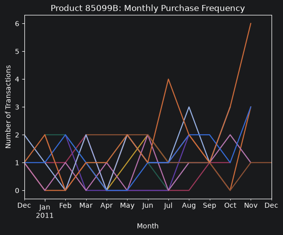

```python
# For each selected product candidate, we examine monthly purchase frequency
# among key customers.
#
# The data is filtered to the selected StockCode and key-customer segment,
# then grouped by customer and resampled monthly to count unique transactions.
#
# A pivot table is used to place months on the x-axis and individual customers
# into separate series, allowing us to see whether demand is driven by one
# customer or repeatedly supported by several key customers over time.
first_candidate_df=customer_df[(customer_df['StockCode']=='85099B') & (customer_df['CustomerID'].isin(leaders))].reset_index(drop=True)

first_candidate=first_candidate_df.groupby('CustomerID').resample('ME', on='InvoiceDate')['InvoiceNo'].nunique().reset_index()

first_candidate['InvoiceDate']=first_candidate['InvoiceDate'].dt.to_period('M')

ax = first_candidate.pivot(index='InvoiceDate', columns='CustomerID', values='InvoiceNo').plot(legend=False)

ax.set_title('Product 85099B: Monthly Purchase Frequency')
ax.set_xlabel('Month')
ax.set_ylabel('Number of Transactions')

# Product 85099B shows the strongest and most consistent purchasing pattern
# among the selected candidates.
#
# Multiple key customers return to the product across different months, and
# several customers purchase it more than once within the same month.
# The product is therefore not dependent on a single buyer or isolated period.
#
# Combined with its leading positions in customer coverage, quantity and
# transaction frequency, 85099B emerges as the strongest candidate for the
# most consistently valued product among key customers.
```

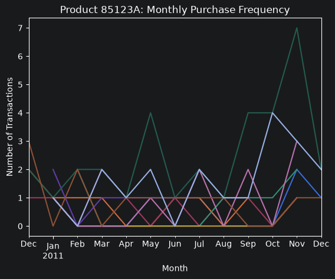

```python
second_candidate_df=customer_df[(customer_df['StockCode']=='85123A') & (customer_df['CustomerID'].isin(leaders))].reset_index(drop=True)

second_candidate=second_candidate_df.groupby('CustomerID').resample('ME', on='InvoiceDate')['InvoiceNo'].nunique().reset_index()

second_candidate['InvoiceDate']=second_candidate['InvoiceDate'].dt.to_period('M')

ax = second_candidate.pivot(index='InvoiceDate', columns='CustomerID', values='InvoiceNo').plot(legend=False)

ax.set_title('Product 85123A: Monthly Purchase Frequency')
ax.set_xlabel('Month')
ax.set_ylabel('Number of Transactions')

# Product 85123A also demonstrates strong recurring demand among key customers.
#
# Purchasing activity is distributed across several customers and different
# months, with most active buyers returning to the product more than once over
# the analyzed period.
#
# Although the pattern is somewhat less consistently strong than for 85099B,
# the product still shows clear evidence of repeated purchasing across the
# key-customer segment.
```

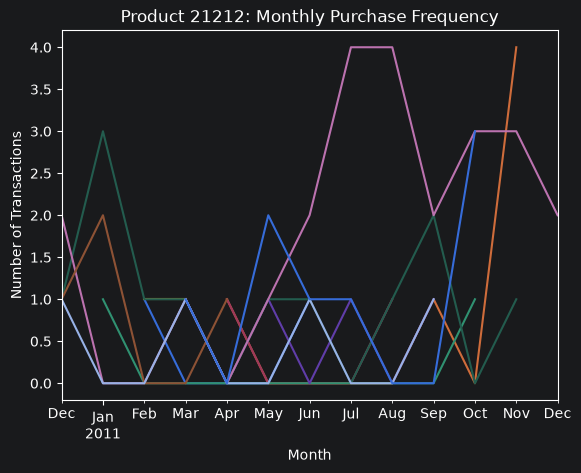

```python
third_candidate_df=customer_df[(customer_df['StockCode']==21212) & (customer_df['CustomerID'].isin(leaders))].reset_index(drop=True)

third_candidate=third_candidate_df.groupby('CustomerID').resample('ME', on='InvoiceDate')['InvoiceNo'].nunique().reset_index()

third_candidate['InvoiceDate']=third_candidate['InvoiceDate'].dt.to_period('M')

ax = third_candidate.pivot(index='InvoiceDate', columns='CustomerID', values='InvoiceNo').plot(legend=False)

ax.set_title('Product 21212: Monthly Purchase Frequency')
ax.set_xlabel('Month')
ax.set_ylabel('Number of Transactions')

# Product 21212 shows a weaker but still meaningful recurring purchasing pattern.
#
# Several key customers return to the product over time, although purchasing
# activity is more uneven and concentrated than for 85099B and 85123A.
#
# Nevertheless, its strong overall ranking together with repeated purchases
# from multiple key customers supports its inclusion among the segment's
# consistently valued products.
```

```python
# Retrieve the product descriptions for the three strongest candidates identified
# among key customers, allowing the final results to be interpreted using actual
# product names rather than StockCodes.

products_df[products_df['StockCode'].astype(str).isin(['85099B', '85123A', '21212'])].groupby('StockCode')['Description'].first()
```

```
StockCode
21212        PACK OF 72 RETROSPOT CAKE CASES
85099B               JUMBO BAG RED RETROSPOT
85123A    WHITE HANGING HEART T-LIGHT HOLDER
Name: Description, dtype: object
```

### Favorite Products Among Key Customers

All three selected products demonstrate **repeated demand among multiple key customers**, rather than being driven by a single buyer or an isolated purchasing spike.

Interestingly, these products are already familiar from the earlier **product analysis**, where they repeatedly appeared among the leaders across different product-level metrics. Their strong performance among key customers therefore reinforces their importance from another perspective: they are not only successful across the store overall, but are also repeatedly purchased by some of its most important customers.

Among them, **JUMBO BAG RED RETROSPOT (85099B)** stands out as the strongest favorite. It combines broad customer coverage, high purchase frequency, and particularly consistent repeated demand over time. Multiple key customers return to the product across different months, often purchasing it in several separate transactions within the same month.

**WHITE HANGING HEART T-LIGHT HOLDER (85123A)** also demonstrates a strong recurring purchasing pattern. Although its monthly activity varies considerably between individual customers, repeated purchases are visible across much of the analyzed period and among several key customers.

**PACK OF 72 RETROSPOT CAKE CASES (21212)** shows a similar, though somewhat weaker, pattern. It is repeatedly purchased by multiple key customers, but its demand is less consistent than that observed for the other two products.

Overall, all three products can be considered **favorites among the store's key customers**, while **JUMBO BAG RED RETROSPOT emerges as the clearest favorite**. Its combination of strong overall product performance and exceptionally persistent demand among key customers makes it particularly notable.

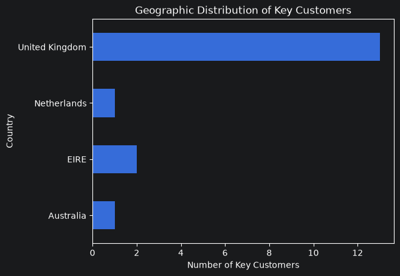

```python
ax = customer_df[customer_df['CustomerID'].isin(leaders)].groupby('Country')['CustomerID'].nunique().plot(kind='barh')

ax.set_xlabel('Number of Key Customers')
ax.set_title('Geographic Distribution of Key Customers')

# The geographic distribution of key customers closely reflects the store's overall
# customer structure. The United Kingdom strongly dominates with 13 of the 17 key
# customers, followed by EIRE with 2, while the Netherlands and Australia are
# represented by one key customer each.
#
# This result is consistent with the earlier geographic analysis, which identified
# the United Kingdom as the store's dominant domestic market. Therefore, the strong
# concentration of key customers in the UK is expected and reinforces the broader
# geographic pattern observed throughout the dataset.
```

## Customer Analysis Summary

The customer analysis reveals a **small but persistent core of highly important buyers**, both in terms of purchasing frequency and financial contribution. Customer activity is strongly concentrated: only **25 customers completed more than 37 transactions**, while only **38 customers generated more than £25,000 in revenue** during the analyzed period.

The strongest customers also demonstrate considerable **stability over time**. In particular, **Customers 12748 and 14911** consistently remain among the transaction-frequency leaders, while several of the highest-revenue customers repeatedly appear among the leading contributors across different periods.

Four customers illustrate particularly well the different forms that customer importance can take. **Customer 14911** combines exceptionally high transaction frequency with top-level revenue, making them one of the clearest examples of a consistently valuable customer. **Customer 14646** represents another strong all-round profile, ranking **1st by total revenue** while also appearing among the most frequent buyers. In contrast, **Customer 12748** ranks **1st by transaction frequency** without reaching the top 10 by revenue, while **Customer 18102** shows the opposite pattern, ranking **2nd by revenue** without appearing among the top 10 by transaction frequency. Together, these cases demonstrate that customer importance cannot be described by a single metric.

The analysis also identified several products with particularly strong recurring demand among key customers. **JUMBO BAG RED RETROSPOT (85099B)** emerges as the clearest favorite, while **WHITE HANGING HEART T-LIGHT HOLDER (85123A)** and **PACK OF 72 RETROSPOT CAKE CASES (21212)** also show repeated purchasing across multiple leading customers. Notably, all three products had already appeared among the leaders in the earlier product analysis, reinforcing their importance to the store.

Geographically, key customers closely reflect the store's broader market structure: **13 of the 17 key customers are located in the United Kingdom**, followed by **EIRE with 2**, and the **Netherlands and Australia with 1 each**.

Finally, the revenue analysis revealed two exceptional bulk-purchasing cases. **Customer 17450** generated an unusually large Q3 contribution through high-volume purchases of relatively inexpensive products, while **Customer 16446** was responsible for the previously identified **"PAPER CRAFT, LITTLE BIRDIE" anomaly** — a single purchase of 80,995 units generating £168,469.60.

Overall, the store's customer base is characterized by a **stable core of highly active and high-value customers, several recurring favorite products, and a small number of exceptional bulk-purchase anomalies**. The results also show that customer value is multidimensional: some customers stand out through frequency, others through revenue, while the strongest combine both.

## Returns Analysis

This section examines the structure of **product returns** and how return activity differs across transactions, products, geographic markets and customers.

We begin by comparing returns with regular sales transactions to understand their overall scale and structure. The analysis then explores the **geographic distribution of returns** and identifies the countries where return activity is most prominent.

At the product level, we examine the **most frequently returned products**, the quantities involved, and the **financial impact of returns**. We also distinguish between products associated with recurring returns and those affected by unusually large individual return events.

Finally, the analysis shifts to the **customer level**, identifying the leading customers by both the **number of return transactions** and the **total quantity of products returned**, while examining how their return activity develops over time.

Overall, the objective is to identify the main patterns behind returns, evaluate their financial significance, highlight unusual cases, and determine how return activity is distributed across the store's products, markets and customers.

### Returns Data Preparation

```python
# Before creating a return-focused dataset, we first inspect how returns are
# represented in the original data and verify their key characteristics.
df[df['InvoiceNo'].astype(str).str.contains('^C')]
```

|  | InvoiceNo | StockCode | Description | Quantity | InvoiceDate | UnitPrice | CustomerID | Country |
| --- | --- | --- | --- | --- | --- | --- | --- | --- |
| 141 | C536379 | D | Discount | -1 | 2010-12-01 09:41:00 | 27.50 | 14527.0 | United Kingdom |
| 154 | C536383 | 35004C | SET OF 3 COLOURED FLYING DUCKS | -1 | 2010-12-01 09:49:00 | 4.65 | 15311.0 | United Kingdom |
| 235 | C536391 | 22556 | PLASTERS IN TIN CIRCUS PARADE | -12 | 2010-12-01 10:24:00 | 1.65 | 17548.0 | United Kingdom |
| 236 | C536391 | 21984 | PACK OF 12 PINK PAISLEY TISSUES | -24 | 2010-12-01 10:24:00 | 0.29 | 17548.0 | United Kingdom |
| 237 | C536391 | 21983 | PACK OF 12 BLUE PAISLEY TISSUES | -24 | 2010-12-01 10:24:00 | 0.29 | 17548.0 | United Kingdom |
| ... | ... | ... | ... | ... | ... | ... | ... | ... |
| 535188 | C581490 | 23144 | ZINC T-LIGHT HOLDER STARS SMALL | -11 | 2011-12-09 09:57:00 | 0.83 | 14397.0 | United Kingdom |
| 536280 | C581499 | M | Manual | -1 | 2011-12-09 10:28:00 | 224.69 | 15498.0 | United Kingdom |
| 536447 | C581568 | 21258 | VICTORIAN SEWING BOX LARGE | -5 | 2011-12-09 11:57:00 | 10.95 | 15311.0 | United Kingdom |
| 536448 | C581569 | 84978 | HANGING HEART JAR T-LIGHT HOLDER | -1 | 2011-12-09 11:58:00 | 1.25 | 17315.0 | United Kingdom |
| 536449 | C581569 | 20979 | 36 PENCILS TUBE RED RETROSPOT | -5 | 2011-12-09 11:58:00 | 1.25 | 17315.0 | United Kingdom |

9251 rows × 8 columns

```python
df[df['InvoiceNo'].astype(str).str.contains('^C')]['Quantity'].count()
```

```
np.int64(9251)
```

```python
df[(df['InvoiceNo'].astype(str).str.contains('^C')) & (df['UnitPrice']<0)]['Quantity'].count()
```

```
np.int64(0)
```

```python
df[(df['InvoiceNo'].astype(str).str.contains('^C')) & (df['Quantity']<0)]['Quantity'].count()

# All records with invoice numbers starting with "C" have negative quantities,
# confirming that negative Quantity values are consistently used to represent returns.
#
# At the same time, none of these records have negative UnitPrice values.
# However, the return records still contain several non-product StockCodes,
# such as operational adjustments and other entries that should not be treated
# as actual returned products.
```

```
np.int64(9251)
```

```python
# To isolate actual product returns, we remove the previously identified
# non-revenue StockCodes and exclude records with zero or negative UnitPrice.
#
# The resulting returns_df therefore contains only return transactions associated
# with actual products and positive recorded prices.
non_revenue_codes = ['POST','DOT','C2','D','M','m','BANK CHARGES','AMAZONFEE','CRUK','B','S']

returns_df=df[(~df['StockCode'].astype(str).isin(non_revenue_codes)) & (df['UnitPrice']>0) & (df['InvoiceNo'].astype(str).str.contains('^C'))].reset_index(drop=True)
```

### Returns vs Normal Orders

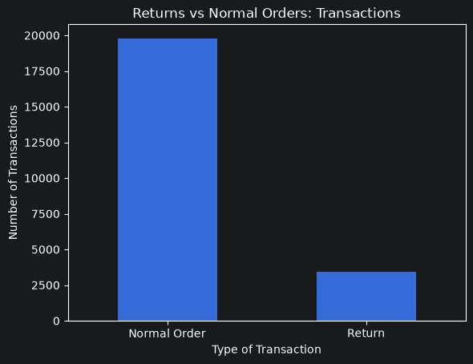

```python
# Prepare a common dataset for a direct comparison between returns and normal orders.
# Non-revenue records and transactions with non-positive prices are excluded.
cleaned_df=df[(~df['StockCode'].astype(str).isin(non_revenue_codes)) & (df['UnitPrice']>0)].reset_index(drop=True)

# Classify each transaction as either a return or a normal order.
cleaned_df['IsReturn']=np.where(cleaned_df['InvoiceNo'].astype(str).str.contains('^C'), 'Return', 'Normal Order')

# Use absolute quantities so returned and purchased quantities can be compared directly.
cleaned_df['Quantity']=abs(cleaned_df['Quantity'])
cleaned_df['Revenue']=cleaned_df['UnitPrice']*cleaned_df['Quantity']

# Compare the number of unique transactions in both groups.
returns_vs_normal_transactions=cleaned_df.groupby('IsReturn')['InvoiceNo'].nunique()

ax = returns_vs_normal_transactions.plot(x='IsReturn', y='InvoiceNo', kind='bar')
ax.set_xlabel('Type of Transaction')
ax.set_ylabel('Number of Transactions')
ax.set_title('Returns vs Normal Orders: Transactions')
ax.tick_params(axis='x', rotation=0)

# Returns represent a relatively small share of all transactions compared with
# normal orders. This suggests that the majority of purchases are completed
# without a recorded return.
#
# The relatively low return frequency may be viewed as a positive indicator,
# although the dataset does not provide enough information to directly determine
# the reasons behind returns or evaluate overall product/service quality.
```

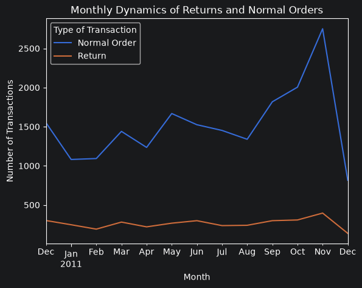

```python
# Examine the monthly dynamics of returns and normal orders.
returns_vs_normal_transactions_dynamic=cleaned_df.groupby('IsReturn').resample('ME', on='InvoiceDate')['InvoiceNo'].nunique().reset_index()

returns_vs_normal_transactions_dynamic['InvoiceDate']=returns_vs_normal_transactions_dynamic['InvoiceDate'].dt.to_period('M')

returns_vs_normal_transactions_pivot= returns_vs_normal_transactions_dynamic.pivot(index='InvoiceDate', columns='IsReturn', values='InvoiceNo')

ax = returns_vs_normal_transactions_pivot.plot()

ax.set_xlabel('Month')
ax.set_ylabel('Number of Transactions')
ax.set_title('Monthly Dynamics of Returns and Normal Orders')
ax.legend(title='Type of Transaction')
```

```python
# Measure the relationship between monthly normal-order and return volumes.
returns_vs_normal_transactions_pivot['Normal Order'].corr(returns_vs_normal_transactions_pivot['Return'])
```

```
np.float64(0.9170768123702556)
```

```python
# Recalculate the correlation excluding incomplete December 2011 to verify
# that the truncated final month does not materially affect the result.
returns_vs_normal_transactions_pivot[returns_vs_normal_transactions_pivot.index!='2011-12']['Normal Order'].corr(returns_vs_normal_transactions_pivot['Return'])

# Returns closely follow the overall transaction dynamics of the store.
# Months with higher normal-order activity generally also experience more returns,
# while quieter periods tend to show fewer returns.
#
# This relationship is supported by a strong positive correlation of approximately
# 0.92 between monthly normal-order and return volumes. After excluding incomplete
# December 2011, the correlation remains similarly strong at approximately 0.91.
#
# No major return-specific anomalies are visible in the monthly dynamics. Overall,
# returns appear to scale with the store's general level of transaction activity
# rather than following a substantially different temporal pattern.
```

```
np.float64(0.910244914352066)
```

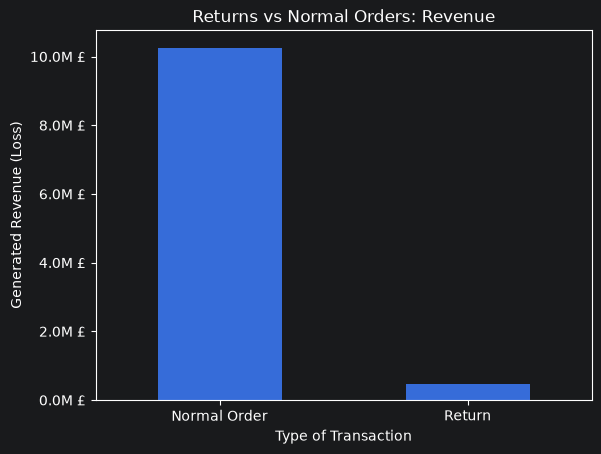

```python
# Compare the total financial value of normal orders and returns.
returns_vs_normal_revenue=cleaned_df.groupby('IsReturn')['Revenue'].sum()

ax = returns_vs_normal_revenue.plot(x='IsReturn', y='Revenue', kind='bar')
ax.set_xlabel('Type of Transaction')
ax.set_ylabel('Generated Revenue (Loss)')
ax.set_title('Returns vs Normal Orders: Revenue')
ax.tick_params(axis='x', rotation=0)
from matplotlib.ticker import FuncFormatter

ax.yaxis.set_major_formatter(FuncFormatter(lambda x, pos: f'{x / 1_000_000:.1f}M £'))

# Returns account for a substantially smaller share of the store's financial
# activity than normal orders.
#
# Their relative financial impact is even smaller than their share of the total
# number of transactions observed earlier. This suggests that returned orders
# tend to involve lower monetary values than normal purchases.
#
# Overall, returns represent a relatively limited direct loss of sales revenue
# compared with the revenue generated by normal orders.
```

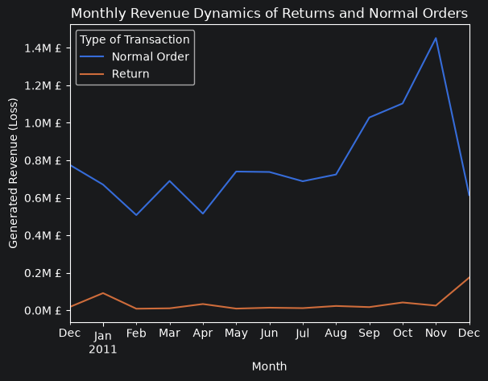

```python
# Compare the monthly financial value of returns and normal orders.
returns_vs_normal_revenue_dynamic=cleaned_df.groupby('IsReturn').resample('ME', on='InvoiceDate')['Revenue'].sum().reset_index()

# Reshape the data to compare both transaction types over time.
returns_vs_normal_revenue_dynamic['InvoiceDate']=returns_vs_normal_revenue_dynamic['InvoiceDate'].dt.to_period('M')

returns_vs_normal_revenue_pivot=returns_vs_normal_revenue_dynamic.pivot(index='InvoiceDate', columns='IsReturn', values='Revenue')

ax = returns_vs_normal_revenue_pivot.plot()
ax.set_xlabel('Month')
ax.set_ylabel('Generated Revenue (Loss)')
ax.set_title('Monthly Revenue Dynamics of Returns and Normal Orders')
ax.yaxis.set_major_formatter(FuncFormatter(lambda x, pos: f'{x / 1_000_000:.1f}M £'))
ax.legend(title='Type of Transaction')
```

```python
# Unlike transaction counts, the monthly monetary value of returns does not
# closely follow the revenue dynamics of normal orders.
returns_vs_normal_revenue_pivot['Normal Order'].corr(returns_vs_normal_revenue_pivot['Return'])
```

```
np.float64(-0.16054897003334048)
```

```python
# Exclude incomplete December 2011 to verify that the result is not driven
# by the partial final month of the dataset.
returns_vs_normal_revenue_pivot[returns_vs_normal_revenue_pivot.index!='2011-12']['Normal Order'].corr(returns_vs_normal_revenue_pivot['Return'])

# No clear return-specific wave or persistent anomaly is visible over time.
# However, unlike the number of return transactions, the monetary value of
# returns does not follow the store's normal revenue dynamics.
#
# The correlation between normal-order revenue and return value is weak
# (-0.16), and becomes effectively zero (0.03) after excluding the incomplete
# December 2011 period.
#
# This suggests that return frequency is largely associated with the store's
# overall transaction activity, while the financial impact of returns is
# driven by additional factors. Further analysis of returned quantities and
# product prices is therefore required.
```

```
np.float64(0.03206627226838539)
```

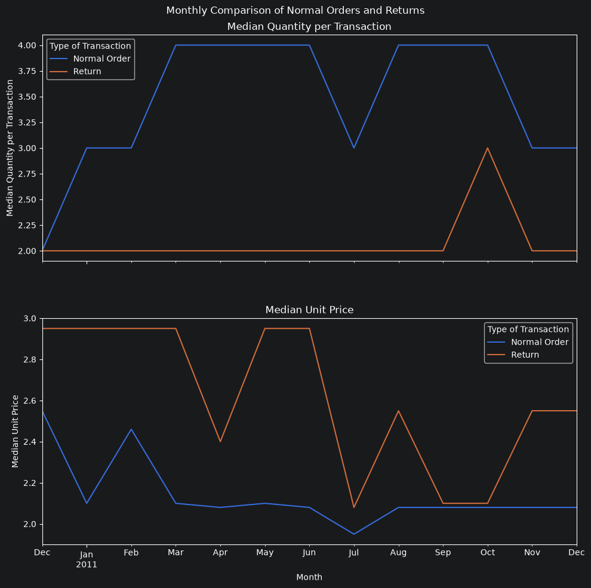

```python
# Examine whether the financial structure of returns can be explained by
# differences in the typical quantity and unit price of returned products.
quantity_and_price = cleaned_df.groupby('IsReturn').resample('ME', on='InvoiceDate')[['Quantity', 'UnitPrice']].median().reset_index()

quantity_and_price['InvoiceDate']=quantity_and_price['InvoiceDate'].dt.to_period('M')

# Reshape quantity and price separately for a monthly comparison between
# normal orders and returns.
quantity_pivot=quantity_and_price.pivot(index='InvoiceDate', columns='IsReturn', values='Quantity')
price_pivot=quantity_and_price.pivot(index='InvoiceDate', columns='IsReturn', values='UnitPrice')

fig, axes = plt.subplots(2,1, figsize=(10,10), sharex=True)

quantity_pivot.plot(ax=axes[0])
price_pivot.plot(ax=axes[1])

axes[0].set_ylabel('Median Quantity per Transaction')
axes[1].set_ylabel('Median Unit Price')

axes[1].set_xlabel('Month')

axes[0].legend(title='Type of Transaction')
axes[1].legend(title='Type of Transaction')

axes[0].set_title('Median Quantity per Transaction')
axes[1].set_title('Median Unit Price')

fig.suptitle('Monthly Comparison of Normal Orders and Returns')
plt.tight_layout(h_pad=5)

# Returned transaction lines generally contain fewer units than normal
# purchases, while the median unit price of returned products tends to be higher.
#
# This pattern remains relatively consistent across the analyzed months,
# although the smaller number of returns makes their monthly medians more
# sensitive to changes in the composition of returned products.
```

```python
# Compare the full distributions of quantity and unit price to verify whether
# the patterns observed in the monthly medians also hold across the dataset.
cleaned_df.groupby('IsReturn')[['UnitPrice', 'Quantity']].quantile([0.25, 0.5, 0.75, 0.9, 0.95])

# The quantile comparison confirms the patterns observed in the monthly data.
#
# Across most of the distribution, returns involve smaller quantities than
# normal purchases. At the median, a returned transaction line contains
# 2 units compared with 4 units for a normal purchase.
#
# Returned products also tend to have higher unit prices across the entire
# analyzed distribution. The difference becomes particularly visible in the
# upper quantiles: at the 95th percentile, returned products have a unit price
# of £12.75 compared with £9.95 for normal purchases.
#
# The upper tail of the quantity distribution is an exception: at the 95th
# percentile, return quantities exceed normal-order quantities (36 vs 30),
# indicating that some returns involve relatively large product quantities.
```

| IsReturn |  | UnitPrice | Quantity |
| --- | --- | --- | --- |
| Normal Order | 0.25 | 1.25 | 1.0 |
|  | 0.50 | 2.08 | 4.0 |
|  | 0.75 | 4.13 | 12.0 |
|  | 0.90 | 7.62 | 24.0 |
|  | 0.95 | 9.95 | 30.0 |
| Return | 0.25 | 1.45 | 1.0 |
|  | 0.50 | 2.55 | 2.0 |
|  | 0.75 | 4.95 | 6.0 |
|  | 0.90 | 9.95 | 20.0 |
|  | 0.95 | 12.75 | 36.0 |

Returns represent a **relatively small share of the store's overall activity**, both in terms of transaction count and financial value. Their share of total revenue is even smaller than their share of transactions, indicating that returns generally have a limited impact on the store's overall sales revenue.

The **number of returns closely follows the store's general transaction activity**. Monthly return and normal-order volumes show a strong positive correlation of approximately **0.92** (**0.91** after excluding incomplete December 2011), suggesting that periods with more purchases naturally generate more returns rather than revealing a separate return-specific trend.

However, the **financial value of returns behaves differently**. Return value shows almost no relationship with normal-order revenue over time, indicating that the financial impact of returns depends not only on how many returns occur, but also on the characteristics of the products being returned.

Further analysis reveals a distinct return structure. Returned transaction lines generally contain **fewer units**, while the returned products tend to have **higher unit prices** than those in normal purchases. This pattern is visible both in monthly medians and across the overall distributions, although the upper tail also contains some relatively large-quantity returns.

Overall, returns appear to be a **limited and structurally distinct part of the store's activity**. Their frequency largely scales with overall transaction volume, while their financial impact is influenced more strongly by the **quantity and price composition of individual returns**.

### Geographic Structure of Returns

```python
# Examine the geographic distribution of returns by comparing the number of
# unique return transactions across countries.
returns_df.groupby('Country')['InvoiceNo'].nunique().sort_values(ascending=False)

# The United Kingdom overwhelmingly dominates the number of returns, followed
# at a considerable distance by Germany, EIRE and France.
#
# This result is consistent with the store's overall geographic structure:
# the UK is also by far the largest market by transaction volume. Therefore,
# the high absolute number of UK returns does not by itself indicate unusually
# high return activity.
```

```
Country
United Kingdom        3029
Germany                135
EIRE                    65
France                  59
Belgium                 19
Switzerland             18
Italy                   14
Spain                   12
Australia               11
Sweden                   8
Channel Islands          6
Japan                    6
Portugal                 6
Poland                   5
Finland                  4
Malta                    4
Netherlands              3
Cyprus                   3
Austria                  2
Denmark                  2
USA                      2
Norway                   2
Czech Republic           2
Bahrain                  1
European Community       1
Israel                   1
Hong Kong                1
Saudi Arabia             1
Name: InvoiceNo, dtype: int64
```

```python
# Check whether the geographic leader in returns remains consistent over time
# by identifying the country with the highest number of return transactions
# in each month.
returns_transactions_geography_dynamic=returns_df.groupby('Country').resample('ME', on='InvoiceDate')['InvoiceNo'].nunique().sort_values(ascending=False).reset_index()

returns_transactions_geography_dynamic.resample('ME', on='InvoiceDate')[['InvoiceNo', 'Country']].head(1)

# The United Kingdom remains the leading country by number of returns in every
# analyzed month. Since no change in the geographic leader is observed, a
# separate monthly visualization would provide little additional information.
```

|  | InvoiceNo | Country |
| --- | --- | --- |
| 1 | 274 | United Kingdom |
| 7 | 217 | United Kingdom |
| 11 | 167 | United Kingdom |
| 5 | 255 | United Kingdom |
| 10 | 197 | United Kingdom |
| 6 | 244 | United Kingdom |
| 2 | 272 | United Kingdom |
| 8 | 214 | United Kingdom |
| 9 | 205 | United Kingdom |
| 4 | 257 | United Kingdom |
| 3 | 268 | United Kingdom |
| 0 | 341 | United Kingdom |
| 12 | 118 | United Kingdom |

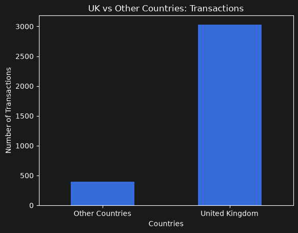

```python
# Compare the total number of return transactions in the UK with all other
# countries combined to illustrate the scale of the geographic concentration.
returns_geography_df=returns_df.copy()
returns_geography_df['IsUK']=np.where(returns_geography_df['Country']=='United Kingdom', 'United Kingdom', 'Other Countries')

ax = returns_geography_df.groupby('IsUK')['InvoiceNo'].nunique().plot(x='IsUK', y='InvoiceNo', kind='bar')

ax.set_xlabel('Countries')
ax.set_ylabel('Number of Transactions')
ax.set_title('UK vs Other Countries: Transactions')
ax.tick_params(axis='x', rotation=0)

# The comparison confirms the strong geographic concentration of returns in
# the United Kingdom. Even when all other countries are combined, their total
# number of return transactions remains substantially below the UK level.
#
# Together with the monthly analysis above, this shows that the UK dominates
# the absolute number of returns both overall and consistently over time.
#
# However, this largely reflects the store's overall concentration in the UK
# market and does not necessarily imply a higher propensity to return products.
```

```python
# Compare the quantity and unit-price distributions of returns between the UK
# and international markets to identify potential geographic differences.
returns_geography_df.groupby('IsUK')[['Quantity', 'UnitPrice']].quantile([0.25, 0.5, 0.75, 0.9, 0.95])

# Returned product prices are almost identical between the UK and international
# markets across the distribution, suggesting no meaningful geographic difference
# in the typical price of returned products.
#
# Return quantities, however, show a clearer difference. International return
# lines tend to involve larger quantities, particularly in the lower and middle
# parts of the distribution. The median international return contains 3 units
# compared with 2 units in the UK, while the 25th percentile differs by 9 vs 6 units
# in absolute terms.
#
# At the upper quantiles, the quantity distributions converge, indicating that
# larger returns occur at broadly similar scales in both markets.
#
# The dataset does not provide sufficient information to determine why typical
# international returns involve larger quantities.
```

| IsUK |  | Quantity | UnitPrice |
| --- | --- | --- | --- |
| Other Countries | 0.25 | -9.0 | 1.45 |
|  | 0.50 | -3.0 | 2.55 |
|  | 0.75 | -1.0 | 4.95 |
|  | 0.90 | -1.0 | 9.95 |
|  | 0.95 | -1.0 | 12.50 |
| United Kingdom | 0.25 | -6.0 | 1.45 |
|  | 0.50 | -2.0 | 2.55 |
|  | 0.75 | -1.0 | 4.95 |
|  | 0.90 | -1.0 | 9.95 |
|  | 0.95 | -1.0 | 12.75 |

Returns are **strongly concentrated in the United Kingdom**, which accounts for substantially more return transactions than all international markets combined. The UK remains the leading country in every analyzed month.

However, this concentration largely reflects the store's overall geographic structure, as the UK also dominates its general transaction activity. Therefore, the high absolute number of UK returns does not by itself indicate a greater tendency to return products.

A more notable geographic difference appears in the **quantity of returned products**. International return lines typically contain more units than UK returns: the median is **3 units internationally compared with 2 units in the UK**, while the 25th percentile is **9 vs 6 units in absolute terms**. This difference disappears toward the upper end of the distribution.

In contrast, **returned product prices are almost identical** between the UK and international markets across the analyzed quantiles.

Overall, geography appears to have **limited influence on the structure of returns**, with the main observed difference being somewhat larger typical return quantities in international transactions. The available data does not provide enough information to determine the reason behind this pattern.

### Product Returns

```python
# Check whether product descriptions contain any missing values before starting
# the product-level return analysis.
returns_df['Description'].isna().sum()

# No missing product descriptions are present in the returns dataset.
# Therefore, no additional description recovery or mapping is required.
```

```
np.int64(0)
```

```python
# Identify the products associated with the highest number of unique return
# transactions. StockCode is used as the product identifier, while the most
# common description is retained as a readable product name.
product_returns_transactions=returns_df.groupby('StockCode')[['InvoiceNo', 'Description']].agg({'InvoiceNo':'nunique', 'Description': lambda x: x.value_counts().index[0]}).sort_values('InvoiceNo', ascending=False).head()

product_returns_transactions

# "REGENCY CAKESTAND 3 TIER" is the clear leader, appearing in 180 unique
# return transactions — more than twice as many as the second-ranked product,
# "JAM MAKING SET WITH JARS", with 87.
#
# This result is particularly notable because "REGENCY CAKESTAND 3 TIER"
# was also previously identified among the leading products by number of
# purchase transactions.
#
# However, the high absolute number of returns does not necessarily indicate
# an unusually high return tendency. Since the product is also purchased very
# frequently, its return activity should be compared with its overall purchase
# frequency before drawing further conclusions.
```

| StockCode | InvoiceNo | Description |
| --- | --- | --- |
| 22423 | 180 | REGENCY CAKESTAND 3 TIER |
| 22960 | 87 | JAM MAKING SET WITH JARS |
| 22720 | 73 | SET OF 3 CAKE TINS PANTRY DESIGN |
| 21232 | 57 | STRAWBERRY CERAMIC TRINKET BOX |
| 22699 | 54 | ROSES REGENCY TEACUP AND SAUCER |

```python
# Store the StockCodes of the leading products by number of return transactions
# for further filtering and time-based analysis.
product_codes=product_returns_transactions.index.to_list()
```

```python
# Check whether the unusually high number of returns for "REGENCY CAKESTAND 3 TIER"
# could be driven by a single customer or a very small group of customers.
returns_df[returns_df['StockCode']==22423]['CustomerID'].nunique()

# The product was returned by 116 different customers, indicating that its high
# return count is broadly distributed across customers rather than being caused
# by a single exceptional buyer.
#
# This rules out a customer-specific anomaly similar to the previously identified
# "PAPER CRAFT, LITTLE BIRDIE" case.
```

```
116
```

```python
# Reset the index before grouped resampling and convert return quantities to
# positive values to make the subsequent return-volume analysis easier to interpret.
returns_df = returns_df.reset_index(drop=True)
returns_df['Quantity']=abs(returns_df['Quantity'])

# Aggregate product returns by month, calculating both the total number of units
# returned and the number of unique return transactions for each product.
returned_products_dynamic=returns_df.groupby('StockCode').resample('ME', on='InvoiceDate').agg({'Quantity':'sum', 'InvoiceNo':'nunique'}).reset_index()

returned_products_dynamic['InvoiceDate']=returned_products_dynamic['InvoiceDate'].dt.to_period('M')

# Restore readable product descriptions after aggregation by mapping each
# StockCode to its most common description in the returns dataset.
product_names = returns_df.groupby('StockCode')['Description'].agg(lambda x: x.value_counts().index[0])
returned_products_dynamic['Description'] = returned_products_dynamic['StockCode'].map(product_names)
```

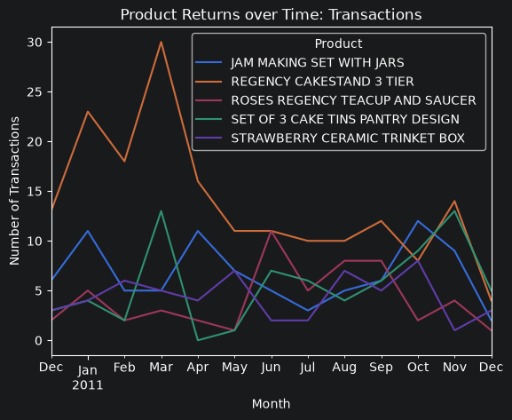

```python
# Examine the monthly dynamics of the five products with the highest overall
# number of return transactions to determine whether their leading positions
# are persistent over time or driven by specific periods.
ax = returned_products_dynamic[returned_products_dynamic['StockCode'].isin(product_codes)].pivot(index='InvoiceDate', columns='Description', values='InvoiceNo').plot()

ax.set_ylabel('Number of Transactions')
ax.set_xlabel('Month')
ax.legend(title='Product')
ax.set_title('Product Returns over Time: Transactions')

# Most of the leading returned products fluctuate within a broadly similar range
# over time. "REGENCY CAKESTAND 3 TIER", however, shows a clearly different pattern.
#
# From December 2010 through approximately April 2011, the product records
# substantially more return transactions than the other leading products,
# reaching its highest level in March 2011.
#
# This period does not correspond to the months with the highest overall
# transaction activity in the dataset, suggesting that the early return peak
# cannot be explained simply by higher store-wide transaction volume.
#
# From around May 2011 onward, its return frequency declines considerably and
# becomes much more comparable with the other leading returned products.
#
# This distinct change in behavior warrants further investigation of the product's
# sales and return activity during the early months of the analyzed period.
```

```python
# Investigate whether the unusually high number of early returns for
# "REGENCY CAKESTAND 3 TIER" is driven by a small number of customers
# repeatedly returning the product.
#
# We focus on the period from December 2010 through May 2011, when the product's
# return activity was substantially higher than that of the other leading products.
returns_df[(returns_df['StockCode']==22423) & (returns_df['InvoiceDate'].between('2010-12-01', '2011-05-31'))].reset_index(drop=True).groupby('CustomerID').resample('ME', on='InvoiceDate')['InvoiceNo'].nunique().reset_index().sort_values('InvoiceNo', ascending=False).head()

# No individual customer appears to explain the unusually high return activity.
# Even the most frequent customer returned the product in only four transactions
# during the examined period, while the remaining leading customers recorded
# similarly low numbers.
#
# Combined with the large number of distinct customers associated with returns
# of this product, this suggests that the early return peak was broadly distributed
# across customers rather than being caused by a single customer or isolated event.
#
# Therefore, although "REGENCY CAKESTAND 3 TIER" shows a clear and unusual increase
# in return frequency during the early months of the dataset, the available data
# does not provide enough information to determine the underlying cause.
```

|  | CustomerID | InvoiceDate | InvoiceNo |
| --- | --- | --- | --- |
| 62 | 15189.0 | 2011-03-31 | 4 |
| 1 | 12471.0 | 2011-01-31 | 3 |
| 48 | 14299.0 | 2011-01-31 | 3 |
| 70 | 15465.0 | 2011-03-31 | 3 |
| 23 | 13089.0 | 2011-05-31 | 2 |

```python
# Identify the products with the largest total number of returned units.
# Return quantities are aggregated by StockCode, while the most common description
# is used to represent each product.

# The six highest-ranking products are retained here instead of five.
# This choice was made after the subsequent investigation of
# "PAPER CRAFT, LITTLE BIRDIE", allowing the analysis to preserve five
# comparable products after that case is examined separately.
product_returns_quantity=returns_df.groupby('StockCode')[['Quantity', 'Description']].agg({'Quantity':'sum', 'Description': lambda x: x.value_counts().index[0]}).sort_values('Quantity', ascending=False).head(6)

product_returns_quantity

# "PAPER CRAFT, LITTLE BIRDIE" appears again, this time as the product with the
# largest total number of returned units, reaching 80,995 units.
#
# The result is particularly notable because the same product was previously
# responsible for an extreme purchase-volume and revenue anomaly.
# Its appearance at the top of the return ranking therefore requires a separate
# investigation to determine whether the two observations are connected.
#
# "MEDIUM CERAMIC TOP STORAGE JAR" also stands out with 74,494 returned units,
# far above the remaining products in the ranking.
```

| StockCode | Quantity | Description |
| --- | --- | --- |
| 23843 | 80995 | PAPER CRAFT , LITTLE BIRDIE |
| 23166 | 74494 | MEDIUM CERAMIC TOP STORAGE JAR |
| 84347 | 9376 | ROTATING SILVER ANGELS T-LIGHT HLDR |
| 21108 | 3150 | FAIRY CAKE FLANNEL ASSORTED COLOUR |
| 85123A | 2578 | WHITE HANGING HEART T-LIGHT HOLDER |
| 21175 | 2030 | GIN + TONIC DIET METAL SIGN |

```python
# Investigate "PAPER CRAFT, LITTLE BIRDIE" after the product unexpectedly
# appears as the leader by total returned quantity.
returns_df.loc[returns_df['StockCode']==23843]

# The entire returned quantity of "PAPER CRAFT, LITTLE BIRDIE" comes from a
# single return transaction: 80,995 units were returned by Customer 16446.
#
# This exactly matches the quantity previously purchased by the same customer.
# The original purchase generated £168,469.60 in revenue and was responsible
# for several extreme outliers identified throughout the analysis.
#
# The matching purchase and return quantities strongly indicate that these
# observations represent two sides of the same exceptional transaction rather
# than normal customer purchasing and return behavior.
```

|  | InvoiceNo | StockCode | Description | Quantity | InvoiceDate | UnitPrice | CustomerID | Country |
| --- | --- | --- | --- | --- | --- | --- | --- | --- |
| 8662 | C581484 | 23843 | PAPER CRAFT , LITTLE BIRDIE | 80995 | 2011-12-09 09:27:00 | 2.08 | 16446.0 | United Kingdom |

```python
# Create a list of the leading products by total returned quantity for further
# filtering and analysis.
#
# "PAPER CRAFT, LITTLE BIRDIE" is excluded after the previous investigation
# showed that its extreme returned quantity comes from a single exceptional
# purchase-and-return case rather than typical return behavior.
product_codes=product_returns_quantity.index.to_list()

product_codes.remove(23843)
```

```python
# Check how many different customers returned each of the remaining products
# with the highest total returned quantities.
#
# This helps determine whether their unusually large return volumes are driven
# by a single exceptional customer or are distributed across multiple customers.
returns_df[returns_df['StockCode'].isin(product_codes)].groupby('StockCode')['CustomerID'].nunique()

# Unlike the previously identified "PAPER CRAFT, LITTLE BIRDIE" anomaly,
# none of the remaining high-quantity products is associated with only one
# customer.
#
# Even "MEDIUM CERAMIC TOP STORAGE JAR", which stands out with an exceptionally
# large total returned quantity, was returned by 10 different customers.
#
# Therefore, the remaining products cannot immediately be explained by the same
# single-customer pattern and require further investigation.
```

```
StockCode
21108      3
21175      6
23166     10
84347      3
85123A    39
Name: CustomerID, dtype: int64
```

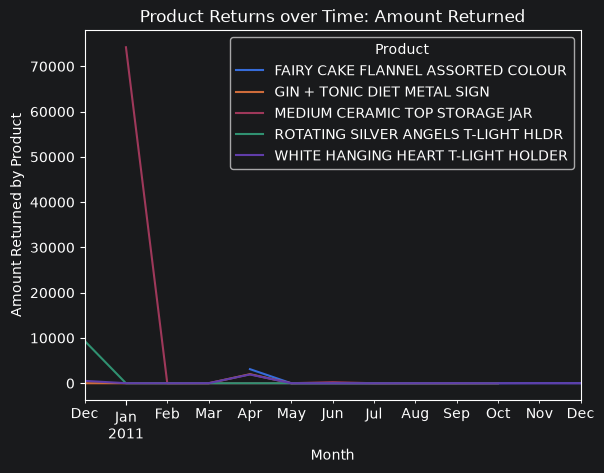

```python
# Examine how the products with the highest total returned quantities behave
# over time after excluding the previously identified extreme single-return case.
ax = returned_products_dynamic[returned_products_dynamic['StockCode'].isin(product_codes)].pivot(index='InvoiceDate', columns='Description', values='Quantity').plot()

ax.set_xlabel('Month')
ax.set_ylabel('Amount Returned by Product')
ax.set_title('Product Returns over Time: Amount Returned')
ax.legend(title='Product')

# Most of the leading products do not show consistently high return quantities
# throughout the analyzed period. Instead, their totals are largely driven by
# isolated spikes concentrated in particular months.
#
# Even products returned by multiple customers therefore appear to accumulate
# most of their returned quantity within relatively short periods rather than
# through persistently elevated returns over time.
#
# The available dataset does not contain enough information to determine why
# several customers returned unusually large quantities of these products
# during these specific periods.
```

```python
# Compare the typical price and total returned quantity across all returned
# products with the price level of the high-quantity return leaders.
returns_df.groupby('StockCode').agg({'UnitPrice':'median', 'Quantity':'sum'}).reset_index()[['UnitPrice','Quantity']].median(), df['UnitPrice'].median()

# The median total returned quantity per product is only 13 units, showing that
# the extremely large quantities observed among the leading products are highly
# unusual relative to typical return activity.
```

```
(UnitPrice     1.95
 Quantity     13.00
 dtype: float64,
 np.float64(2.08))
```

```python
returns_df[returns_df['StockCode'].isin(product_codes)]['UnitPrice'].median()

# At the same time, the median unit price of the return leaders (£2.55) is only
# moderately higher than the median price across all returned products (£1.95).
# Therefore, these extreme return quantities do not appear to be associated
# with unusually expensive products.



# After excluding the previously identified extreme single-return case, the remaining
# products with the largest returned quantities still exhibit highly unusual behavior.
# Their return volumes are substantially larger than those of a typical product, for
# which the median total returned quantity is only 13 units.
#
# However, these extreme quantities are generally concentrated in isolated periods
# rather than sustained throughout the year. Several of the affected products were
# also returned by multiple different customers, suggesting that the observed spikes
# cannot generally be attributed to a single exceptional customer.
#
# The products themselves do not appear unusually expensive. The median unit price
# among the high-quantity return leaders is approximately £2.55, compared with £1.95
# across all returned products.
#
# The available data does not provide information about return reasons, product
# condition, delivery issues, or other operational factors that could explain why
# multiple customers returned unusually large quantities during particular periods.
# Therefore, the underlying causes of these isolated return spikes cannot be reliably
# determined from the dataset.
#
# Overall, the analysis indicates that extremely large returns are rare and highly
# concentrated anomalies rather than a typical feature of customer return behavior.
```

```
np.float64(2.55)
```

Product return behavior is generally characterized by **relatively small quantities and a limited number of transactions**, although several notable exceptions were identified.

By return frequency, **"REGENCY CAKESTAND 3 TIER"** stands out as the clear leader and can be considered the **most consistently returned product in the dataset**. Unlike most other leading returned products, its return activity persists across much of the analyzed period rather than being concentrated in a single isolated spike. Its particularly high return frequency during the early months is also distributed across a large number of customers, although the available data does not provide enough information to determine the underlying reason for this pattern.

The analysis of returned quantities revealed a different type of behavior. Several products accumulated exceptionally large returned quantities, but these volumes were generally **concentrated in isolated periods rather than sustained over time** and involved multiple customers. At the same time, the affected products are not unusually expensive: their median unit price remains relatively close to the overall median price of returned products.

One exceptional case was fully explained. The **80,995-unit return of "PAPER CRAFT, LITTLE BIRDIE"** exactly matches the previously identified purchase of the same quantity by Customer 16446, linking several extreme outliers observed throughout the analysis to a single exceptional purchase-and-return event.

Overall, the return analysis reveals two distinct patterns: **persistent return frequency**, represented most clearly by "REGENCY CAKESTAND 3 TIER", and **rare, highly concentrated return-volume anomalies** affecting several other products. Since the dataset contains no information about return reasons, product condition, delivery issues, or similar operational factors, the causes of the remaining unusual return patterns cannot be reliably determined.